# The short-term association of PM2.5 on stroke: A time-stratified case-crossover study in Berlin, Germany

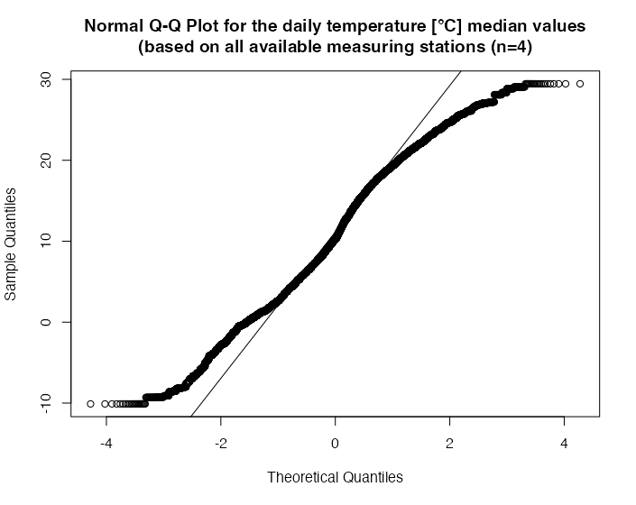

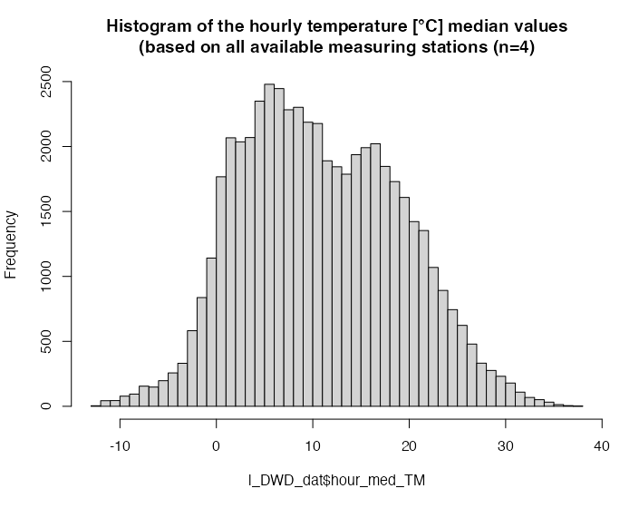

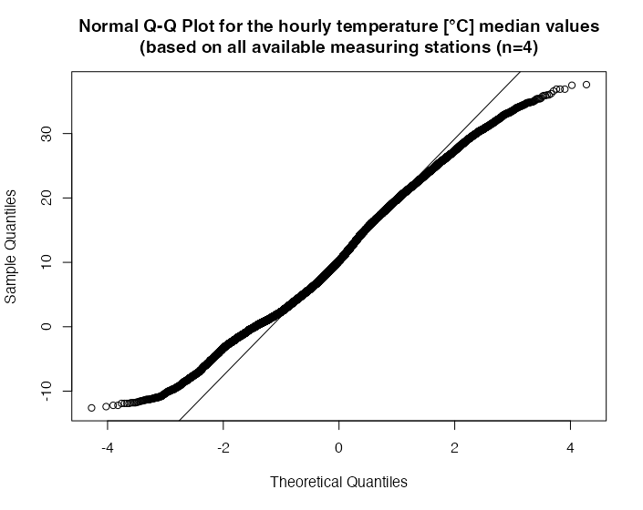

- Histogram and Q-Q-plot for relative humidity

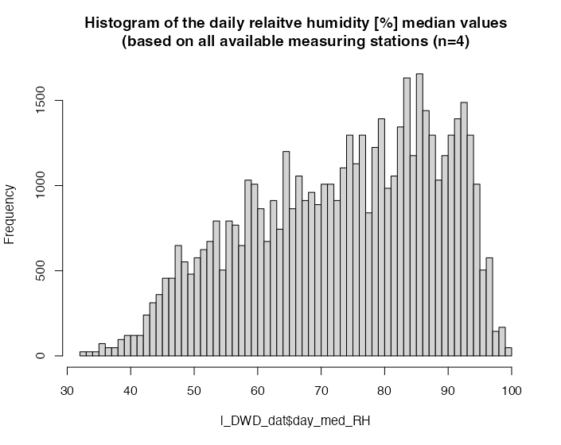

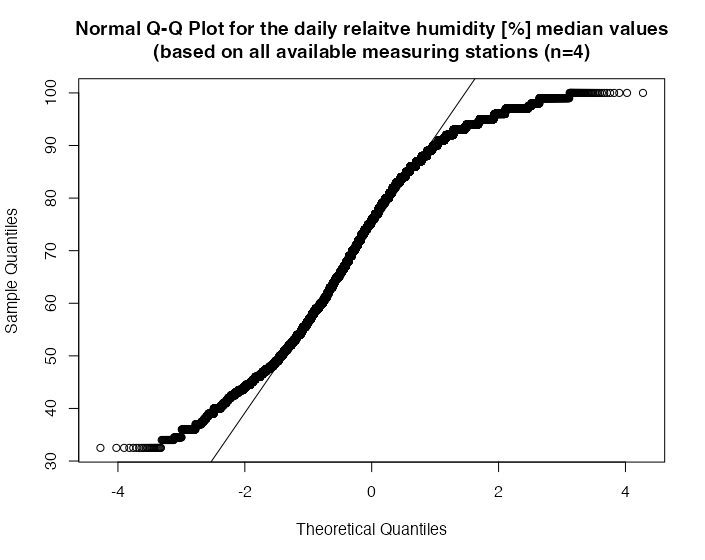

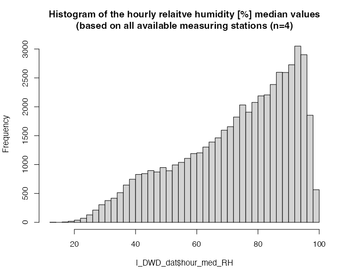

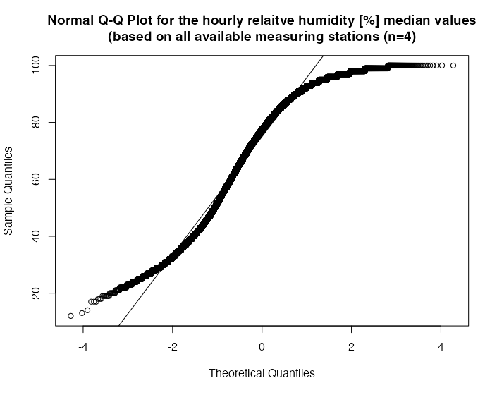

## Methods

### DAG

- Potential confounding variables were identified through literature screening and input from topic experts.
- The resulting causal framework was compiled into a Directed Acyclic Graph (DAG).

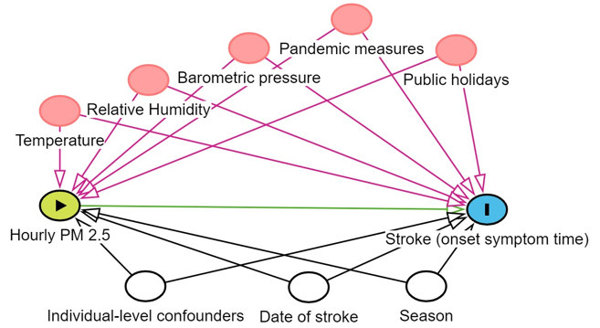

```r
holidays <- date(c("2017-01-01", "2017-03-08", "2017-04-14", "2017-04-17", "2017-05-01", "2017-05-25", "2017-06-05", "2017-10-03", "2017-12-25", "2017-12-26","2017-12-31", "2018-01-01", "2018-03-08", "2018-03-30", "2018-04-02", "2018-05-01", "2018-05-10", "2018-05-21", "2018-10-03", "2018-12-25", "2018-12-26", "2018-12-31", "2019-01-01", "2019-03-08", "2019-04-19", "2019-04-22", "2019-05-01", "2019-05-30", "2019-06-10", "2019-10-03", "2019-12-25", "2019-12-26", "2019-12-31", "2020-01-01", "2020-03-08", "2020-04-10", "2020-04-13", "2020-05-01", "2020-05-21", "2020-06-01", "2020-10-03", "2020-12-25", "2020-12-31"))

first_time <- c("0", "1", "2", "3", "4", "5")
second_time <-  c("6", "7", "8", "9", "10", "11")
third_time <-  c("12", "13", "14", "15", "16", "17")
fourth_time <-  c("18", "19", "20", "21", "22", "23")

dat_total <- dat_analysis_pan_adj %>%
  rename(all_time = all_dates)

dat_total <- dat_total %>%
mutate(weekday = weekdays(all_time)) %>%
  mutate(all_date = date(all_time))

#holidays <- as.Date(holidays)
#dat_total$all_date <- as.Date(dat_total$all_date)
#dat_total$holidays <- ifelse(dat_total$all_date %in% holidays, "Yes", "No")

dat_total <- dat_total %>%
#   mutate(time = as_hms(ymd_hms(all_time)))
  mutate(time = hour(all_time))
# dat_total$time <- hour(dat_total$time)

dat_total <- dat_total  %>%
  mutate(time1 = ifelse(time %in% first_time, "Yes", "No")) %>%
  mutate(time2 = ifelse(time %in% second_time, "Yes", "No")) %>%
  mutate(time3 = ifelse(time %in% third_time, "Yes", "No")) %>%
  mutate(time4 = ifelse(time %in% fourth_time, "Yes", "No"))

summary_time_total1 <- list(
 "Number of strokes at public holiday" = list(
    "Public holiday (%)" = ~ n_perc0(dat_total$holidays == "Yes", na_rm = TRUE, show_denom = "never"),
    "Non public holiday (%)" = ~ n_perc0(dat_total$holidays == "No", na_rm = TRUE, show_denom = "never")),
  "Median PM 2.5 concentrations [µg/m3] at public holiday" = list(
    "Public holiday" = ~ median(dat_total$pm25_median_h[dat_total$holidays == "Yes"], na_rm = TRUE, show_denom = "never"),
    "Non public holiday" = ~ median(dat_total$pm25_median_h[dat_total$holidays == "No"], na_rm = TRUE, show_denom = "never"))
)


tbl_time_total <- summary_table(dat_total, summary_time_total1)




dat_cases <- dat_analysis_pan_adj %>%
  filter(stroke =="1") #%>%

dat_cases <- dat_cases %>%
mutate(weekday = weekdays(case_time)) %>%
  mutate(case_date = date(case_time))

dat_cases <- dat_cases %>%
  mutate(holiday = case_when(adm_time %in% holidays ~ "Yes", TRUE ~ "No")) %>%
#  mutate(time = as_hms(ymd_hms(case_time)))
  mutate(time = hour(case_time))
#dat_cases$time <- hour(dat_cases$time)

dat_cases <- dat_cases  %>%
  mutate(time1 = ifelse(time %in% first_time, "Yes", "No")) %>%
  mutate(time2 = ifelse(time %in% second_time, "Yes", "No")) %>%
  mutate(time3 = ifelse(time %in% third_time, "Yes", "No")) %>%
  mutate(time4 = ifelse(time %in% fourth_time, "Yes", "No"))

summary_time_case1 <- list(
 "Number of strokes at public holiday" = list(
    "Public holiday (%)" = ~ n_perc0(dat_cases$holidays == "Yes", na_rm = TRUE, show_denom = "never"),
    "Non public holiday (%)" = ~ n_perc0(dat_cases$holidays == "No", na_rm = TRUE, show_denom = "never")),
  "Median PM 2.5 concentrations [µg/m3] at public holiday" = list(
    "Public holiday" = ~ median(dat_cases$pm25_median_h[dat_cases$holidays == "Yes"], na_rm = TRUE, show_denom = "never"),
    "Non public holiday" = ~ median(dat_cases$pm25_median_h[dat_cases$holidays == "No"], na_rm = TRUE, show_denom = "never"))
)


tbl_time_case <- summary_table(dat_cases, summary_time_case1)


dat_control <- dat_analysis_pan_adj %>%
  filter(stroke =="0") %>%
  rename(control_time = control_dates)

dat_control <- dat_control %>%
  mutate(weekday = weekdays(control_time)) %>%
  mutate(control_date = date(control_time))

dat_control <- dat_control %>%
#  mutate(time = as_hms(ymd_hms(control_time)))
  mutate(time = hour(control_time))
#dat_control$time <- hour(dat_control$time)

dat_control <- dat_control  %>%
  mutate(time1 = ifelse(time %in% first_time, "Yes", "No")) %>%
  mutate(time2 = ifelse(time %in% second_time, "Yes", "No")) %>%
  mutate(time3 = ifelse(time %in% third_time, "Yes", "No")) %>%
  mutate(time4 = ifelse(time %in% fourth_time, "Yes", "No"))

summary_time_control1 <- list(
 "Number of strokes at public holiday" = list(
    "Public holiday (%)" = ~ n_perc0(dat_control$holidays == "Yes", na_rm = TRUE, show_denom = "never"),
    "Non public holiday (%)" = ~ n_perc0(dat_control$holidays == "No", na_rm = TRUE, show_denom = "never")),
 "Median PM 2.5 concentrations [µg/m3] at public holiday" = list(
    "Public holiday" = ~ median(dat_control$pm25_median_h[dat_control$holidays == "Yes"], na_rm = TRUE, show_denom = "never"),
    "Non public holiday" = ~ median(dat_control$pm25_median_h[dat_control$holidays == "No"], na_rm = TRUE, show_denom = "never"))
)



tbl_time_control <- summary_table(dat_control, summary_time_control1)



# putting columns together and print final version:
table_time_complete <- cbind(tbl_time_total, tbl_time_case, tbl_time_control)
colnames(table_time_complete) <- c(" ", "Total", "Cases", "Controls")
print(table_time_complete, rtitle = "Total number of all cases and controls and median PM 2.5 concentrations stratified by public holiday")
```

|  | dat_total (N = 42,073) | dat_cases (N = 9,565) | dat_control (N = 32,508) |
| --- | --- | --- | --- |
| **Number of strokes at public holiday** |  |  |  |
| Public holiday (%) | 1,337 (3) | 271 (3) | 1,066 (3) |
| Non public holiday (%) | 40,736 (97) | 9,294 (97) | 31,442 (97) |
| **Median PM 2.5 concentrations [µg/m3] at public holiday** |  |  |  |
| Public holiday | 9.02 | 9.45 | 8.92 |
| Non public holiday | 10.05 | 10.17 | 10.02 |

```r
dat_total_pan <- dat_analysis_pan_adj %>%
  rename(all_time = all_dates)

summary_time_total_pan <- list(
 "Number of strokes during and before pandemic measures" = list(
    "During pandemic measures (%)" = ~ n_perc0(dat_total_pan$pandemic == "Yes", na_rm = TRUE, show_denom = "never"),
    "Before pandemic measures (%)" = ~ n_perc0(dat_total_pan$pandemic == "No", na_rm = TRUE, show_denom = "never")),
  "Median PM 2.5 concentrations [µg/m3] during and before pandemic measures" = list(
    "During pandemic measures" = ~ median(dat_total_pan$pm25_median_h[dat_total$holidays == "Yes"], na_rm = TRUE, show_denom = "never"),
    "Before pandemic measures" = ~ median(dat_total_pan$pm25_median_h[dat_total$holidays == "No"], na_rm = TRUE, show_denom = "never"))
)


tbl_time_total_pan <- summary_table(dat_total_pan, summary_time_total_pan)




dat_cases_pan <- dat_analysis_pan_adj %>%
  filter(stroke =="1") #%>%

summary_time_case_pan <- list(
 "Number of strokes during and before pandemic measures" = list(
    "During pandemic measures (%)" = ~ n_perc0(dat_cases_pan$pandemic == "Yes", na_rm = TRUE, show_denom = "never"),
    "Before pandemic measures (%)" = ~ n_perc0(dat_cases_pan$pandemic == "No", na_rm = TRUE, show_denom = "never")),
  "Median PM 2.5 concentrations [µg/m3] during and before pandemic measures" = list(
    "During pandemic measures" = ~ median(dat_cases_pan$pm25_median_h[dat_cases_pan$pandemic == "Yes"], na_rm = TRUE, show_denom = "never"),
    "Before pandemic measures" = ~ median(dat_cases_pan$pm25_median_h[dat_cases_pan$pandemic == "No"], na_rm = TRUE, show_denom = "never"))
)

tbl_time_total_pan_case <- summary_table(dat_cases_pan, summary_time_case_pan)



dat_control_pan <- dat_analysis_pan_adj %>%
  filter(stroke =="0") #%>%

summary_time_control_pan <- list(
 "Number of strokes during and before pandemic measures" = list(
    "During pandemic measures (%)" = ~ n_perc0(dat_control_pan$pandemic == "Yes", na_rm = TRUE, show_denom = "never"),
    "Before pandemic measures (%)" = ~ n_perc0(dat_control_pan$pandemic == "No", na_rm = TRUE, show_denom = "never")),
  "Median PM 2.5 concentrations [µg/m3] during and before pandemic measures" = list(
    "During pandemic measures" = ~ median(dat_control_pan$pm25_median_h[dat_control_pan$pandemic == "Yes"], na_rm = TRUE, show_denom = "never"),
    "Before pandemic measures" = ~ median(dat_control_pan$pm25_median_h[dat_control_pan$pandemic == "No"], na_rm = TRUE, show_denom = "never"))
)

tbl_time_total_pan_control <- summary_table(dat_control_pan, summary_time_control_pan)

# putting columns together and print final version:
table_time_complete_pan <- cbind(tbl_time_total_pan, tbl_time_total_pan_case, tbl_time_total_pan_control)
colnames(table_time_complete_pan) <- c(" ", "Total", "Cases", "Controls")
print(table_time_complete_pan, rtitle = "Total number of all cases and controls and median PM 2.5 concentrations stratified by pandemic")
```

|  | dat_total_pan (N = 42,073) | dat_cases_pan (N = 9,565) | dat_control_pan (N = 32,508) |
| --- | --- | --- | --- |
| **Number of strokes during and before pandemic measures** |  |  |  |
| During pandemic measures (%) | 8,618 (20) | 1,930 (20) | 6,688 (21) |
| Before pandemic measures (%) | 33,455 (80) | 7,635 (80) | 25,820 (79) |
| **Median PM 2.5 concentrations [µg/m3] during and before pandemic measures** |  |  |  |
| During pandemic measures | 9.02 | 8.45 | 8.26 |
| Before pandemic measures | 10.05 | 10.645 | 10.575 |

### Dataset

- The original **time-series data format** was transferred into an **expanded matched case-control structure** (Yao Wu et al., 2021; Armstrong et al., 2014; Zhao, 2016; Mostofsky et al., 2018).
- The **times of the symptom onset were rounded to the fullest hour** to fit the time information to the exposure and adjustment data.

```r
# example_dataset <- dat_analysis %>%
#   select(pat_id_exp, strata, stroke,case_time, control_dates, all_dates, pm25_median_h_Z, hour_med_TM, hour_med_RH) %>%
#   head(20)
#
# print(example_dataset)
```

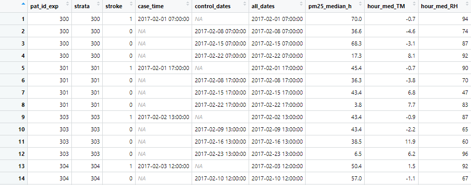

### Main analyses

**Main analyses method**:  
**Conditional logistic regression (CLR)** was applied to assess the association of stroke and PM2.5 short-term exposure. Therefore, the **clogit()-function of the {survival}-package** and the **gam()-function of the {mgcv}-package** was used. Both functions calculate the CLR loglikelihood on the basis of a stratified Cox model (https://www.rdocumentation.org/packages/survival/versions/3.5-7/topics/clogit).  
The **number of degrees for freedom for each meteorological covariate and each model analyses type** was specified by calculating the **Akaike information criterion (AIC)** for a range of potential df from one to ten. The **model with the lowest AIC value** was considered for the main and sensitivity analyses.  
**Adjustments**:  
To adjust for temperature, barometric pressure and relative humidity **natural splines** were included into the **clogit-function**. **Polynomial terms** and the **gam-function** (with the inner s-function) ere conducted as **sensitivity analyses**.  
Recognizing **public holidays and pandemic measures as potential confounders of PM 2.5 concentration and stroke occurrence**, all public holidays between February 2017 and December 2020 and periods with repeated government-mandated pandemic measures were **included as binary indicator variables**.  
**Chosen timeframe of adjustment of pandemic measures**: Starting on March 13, 2020, pandemic-related nationwide measures were implemented (https://www.rki.de/DE/Content/InfAZ/N/Neuartiges_Coronavirus/Situationsberichte/2020-03-14-de.html). From this date until December 31, 2020, routine life was not fully restored, with varying degrees of measures in place throughout the period.  
**Unit of outcome**:  
By z-transforming the PM 2.5 exposure values we defined following outcome unit: “**For each 1 standard deviation increase in (z-transformed) PM 2.5 was associated with an XX times greater odds (adjusted Odds Ratio; aOR) of ischemic stroke (IS) or transient ischemic attack (TIA) (95% CI).**”

### Sensitivity analyses

a) To ensure methodological robustness and validate the results, the main analysis will be conducted with **two other non-linear adjustment methods (polynomial cubic terms vs.splines with given df (clogit::nsk()) vs. splines with automatic received df (mgcv::s()))**, but identical model specifications.  
b) **Time restriction for pandemic measures** in 2020.  
c) **Differentiation into single ischemic stroke (IS) and single transient ischemic attack (TIA) analyses**

## Results

### Models

#### Covariates

**Covariates”“:  
Hourly relative humidity, hourly temperature, hourly barometric pressure, public holidays & pandemic measure periods. (hour_med_RH, hour_med_TM, hour_med_AP, holidays, pandemic)  
Model examples:

- eg. **clogit + natural splines** (df =1) model11_clogit_nsk <- clogit(stroke ~ pm25_median_h_Z_sIQR +strata(strata) + nsk(hour_med_AP, df = 1) + nsk(hour_med_RH, df = 1) + nsk(hour_med_TM, df = 1) + holidays + pandemic,dat_analysis_pan_adj)
- eg. **clogit + polynomial terms** (degree =1) model11_clogit_polynom <- clogit(stroke ~ pm25_median_h_Z_sIQR +strata(strata) + I(hour_med_AP^2) + I(hour_med_AP^1) + I(hour_med_RH^2) + I(hour_med_RH^1) + I(hour_med_TM^2) + I(hour_med_TM^1) + holidays + pandemic,dat_analysis_pan_adj)
- eg. **gam + smooth splines** (calculated df) model11_gam <- gam(cbind(dummy,strata) ~ pm25_median_h_Z_sIQR + s(hour_med_RH) + s(hour_med_TM) + s(hour_med_AP) + holidays + pandemic, data=dat_analysis_pan_adj, family=cox.ph,weights=stroke)

#### Akaike information criterion (AIC)

```r
# loop nsk
model_nsk_df_sum_pan <- list()
df_values <- 1:10
for (df in df_values) {
  model_name <- paste("model_clogit_nsk_df", df, sep = "_")
  model <- clogit(stroke ~ pm25_median_h_Z + strata(strata) +
                    nsk(hour_med_AP, df = df) +
                    nsk(hour_med_RH, df = df) +
                    nsk(hour_med_TM, df = df) +
                    holidays +
                    pandemic, dat_analysis_pan_adj, method = "approximate")
  model_nsk_df_sum_pan[[model_name]] <- model
}

AIC_clogit_nsk_pan <- c(
AIC(model_nsk_df_sum_pan$model_clogit_nsk_df_1),
AIC(model_nsk_df_sum_pan$model_clogit_nsk_df_2),
AIC(model_nsk_df_sum_pan$model_clogit_nsk_df_3),
AIC(model_nsk_df_sum_pan$model_clogit_nsk_df_4),
AIC(model_nsk_df_sum_pan$model_clogit_nsk_df_5),
AIC(model_nsk_df_sum_pan$model_clogit_nsk_df_6),
AIC(model_nsk_df_sum_pan$model_clogit_nsk_df_7),
AIC(model_nsk_df_sum_pan$model_clogit_nsk_df_8),
AIC(model_nsk_df_sum_pan$model_clogit_nsk_df_9),
AIC(model_nsk_df_sum_pan$model_clogit_nsk_df_10))

AIC_clogit_nsk_pan_names <- c(
"model_clogit_nsk_df_1",
"model_clogit_nsk_df_2",
"model_clogit_nsk_df_3",
"model_clogit_nsk_df_4",
"model_clogit_nsk_df_5",
"model_clogit_nsk_df_6",
"model_clogit_nsk_df_7",
"model_clogit_nsk_df_8",
"model_clogit_nsk_df_9",
"model_clogit_nsk_df_10")

AIC_tbl_clogit_nsk_pan_df <- data.frame(Modnames = AIC_clogit_nsk_pan_names, AIC = AIC_clogit_nsk_pan)
AIC_tbl_clogit_nsk_pan_df <- AIC_tbl_clogit_nsk_pan_df %>%
  arrange(AIC)

AIC_tbl_clogit_nsk_pan_df %>%
  knitr::kable() %>%
  kable_styling()
```

| Modnames | AIC |
| --- | --- |
| model_clogit_nsk_df_1 | 28221 |
| model_clogit_nsk_df_2 | 28224 |
| model_clogit_nsk_df_3 | 28228 |
| model_clogit_nsk_df_4 | 28229 |
| model_clogit_nsk_df_6 | 28229 |
| model_clogit_nsk_df_5 | 28230 |
| model_clogit_nsk_df_7 | 28232 |
| model_clogit_nsk_df_8 | 28237 |
| model_clogit_nsk_df_9 | 28239 |
| model_clogit_nsk_df_10 | 28243 |

```r
# loop poly
model_poly_degree_sum_pan <- list()
degree_values <- 1:10
for (degree in degree_values) {
  model_name <- paste("model_clogit_poly_degree", degree, sep = "_")
  model <- clogit(stroke ~ pm25_median_h_Z +
                    strata(strata) +
                    poly(hour_med_AP, degree = degree, raw = TRUE) +
                    poly(hour_med_RH, degree = degree, raw = TRUE) +
                    poly(hour_med_TM, degree = degree, raw = TRUE) +
                    holidays +
                    pandemic,dat_analysis_pan_adj)
  model_poly_degree_sum_pan[[model_name]] <- model
}
AIC_clogit_polynom_pan <- c(
AIC(model_poly_degree_sum_pan$model_clogit_poly_degree_1),
AIC(model_poly_degree_sum_pan$model_clogit_poly_degree_2),
AIC(model_poly_degree_sum_pan$model_clogit_poly_degree_3),
AIC(model_poly_degree_sum_pan$model_clogit_poly_degree_4),
AIC(model_poly_degree_sum_pan$model_clogit_poly_degree_5),
AIC(model_poly_degree_sum_pan$model_clogit_poly_degree_6),
AIC(model_poly_degree_sum_pan$model_clogit_poly_degree_7),
AIC(model_poly_degree_sum_pan$model_clogit_poly_degree_8),
AIC(model_poly_degree_sum_pan$model_clogit_poly_degree_9),
AIC(model_poly_degree_sum_pan$model_clogit_poly_degree_10))

AIC_clogit_polynom_names_pan <- c(
"model_clogit_poly_degree_1",
"model_clogit_poly_degree_2",
"model_clogit_poly_degree_3",
"model_clogit_poly_degree_4",
"model_clogit_poly_degree_5",
"model_clogit_poly_degree_6",
"model_clogit_poly_degree_7",
"model_clogit_poly_degree_8",
"model_clogit_poly_degree_9",
"model_clogit_poly_degree_10")

AIC_tbl_clogit_polynom_degree_pan <- data.frame(Modnames = AIC_clogit_polynom_names_pan, AIC = AIC_clogit_polynom_pan)
AIC_tbl_clogit_polynom_degree_pan <- AIC_tbl_clogit_polynom_degree_pan %>%
  arrange(AIC)

AIC_tbl_clogit_polynom_degree_pan %>%
  knitr::kable() %>%
  kable_styling()
```

| Modnames | AIC |
| --- | --- |
| model_clogit_poly_degree_4 | 28217 |
| model_clogit_poly_degree_1 | 28221 |
| model_clogit_poly_degree_5 | 28223 |
| model_clogit_poly_degree_2 | 28223 |
| model_clogit_poly_degree_6 | 28226 |
| model_clogit_poly_degree_3 | 28228 |
| model_clogit_poly_degree_7 | 28228 |
| model_clogit_poly_degree_8 | 28229 |
| model_clogit_poly_degree_9 | 28230 |
| model_clogit_poly_degree_10 | 28238 |

```r
# AP^1
model_poly_degree_sum_pan <- list()
degree_values <- 1:10
degree_values_AP <- 1:10
for (degree in degree_values){
  model_name <- paste("model_clogit_poly_degree", degree, sep = "_")
  model <- clogit(stroke ~ pm25_median_h_Z +
                    strata(strata) +
                    poly(hour_med_AP, degree = 1, raw = TRUE) +
                    poly(hour_med_RH, degree = degree, raw = TRUE) +
                    poly(hour_med_TM, degree = degree, raw = TRUE) +
                    holidays +
                    pandemic,dat_analysis_pan_adj)
  model_poly_degree_sum_pan[[model_name]] <- model
}
AIC_clogit_polynom_pan <- c(
AIC(model_poly_degree_sum_pan$model_clogit_poly_degree_1),
AIC(model_poly_degree_sum_pan$model_clogit_poly_degree_2),
AIC(model_poly_degree_sum_pan$model_clogit_poly_degree_3),
AIC(model_poly_degree_sum_pan$model_clogit_poly_degree_4),
AIC(model_poly_degree_sum_pan$model_clogit_poly_degree_5),
AIC(model_poly_degree_sum_pan$model_clogit_poly_degree_6),
AIC(model_poly_degree_sum_pan$model_clogit_poly_degree_7),
AIC(model_poly_degree_sum_pan$model_clogit_poly_degree_8),
AIC(model_poly_degree_sum_pan$model_clogit_poly_degree_9),
AIC(model_poly_degree_sum_pan$model_clogit_poly_degree_10))

AIC_clogit_polynom_names_pan <- c(
"model_clogit_poly_degree_1",
"model_clogit_poly_degree_2",
"model_clogit_poly_degree_3",
"model_clogit_poly_degree_4",
"model_clogit_poly_degree_5",
"model_clogit_poly_degree_6",
"model_clogit_poly_degree_7",
"model_clogit_poly_degree_8",
"model_clogit_poly_degree_9",
"model_clogit_poly_degree_10")

AIC_tbl_clogit_polynom_degree_pan <- data.frame(Modnames = AIC_clogit_polynom_names_pan, AIC = AIC_clogit_polynom_pan)
AIC_tbl_clogit_polynom_degree_pan <- AIC_tbl_clogit_polynom_degree_pan %>%
  arrange(AIC)

AIC_tbl_clogit_polynom_degree_pan %>%
  knitr::kable() %>%
  kable_styling()
```

| Modnames | AIC |
| --- | --- |
| model_clogit_poly_degree_4 | 28216 |
| model_clogit_poly_degree_5 | 28219 |
| model_clogit_poly_degree_1 | 28221 |
| model_clogit_poly_degree_10 | 28222 |
| model_clogit_poly_degree_6 | 28223 |
| model_clogit_poly_degree_2 | 28224 |
| model_clogit_poly_degree_7 | 28225 |
| model_clogit_poly_degree_9 | 28225 |
| model_clogit_poly_degree_8 | 28226 |
| model_clogit_poly_degree_3 | 28227 |

```r
# AP^2
model_poly_degree_sum_pan1 <- list()
degree_values <- 1:10
for (degree in degree_values){
  model_name <- paste("model_clogit_poly_degree", degree, sep = "_")
  model <- clogit(stroke ~ pm25_median_h_Z +
                    strata(strata) +
                    poly(hour_med_AP, degree = 2, raw = TRUE) +
                    poly(hour_med_RH, degree = degree, raw = TRUE) +
                    poly(hour_med_TM, degree = degree, raw = TRUE) +
                    holidays +
                    pandemic,dat_analysis_pan_adj)
  model_poly_degree_sum_pan1[[model_name]] <- model
}
AIC_clogit_polynom_pan1 <- c(
  AIC(model_poly_degree_sum_pan1$model_clogit_poly_degree_1),
  AIC(model_poly_degree_sum_pan1$model_clogit_poly_degree_2),
  AIC(model_poly_degree_sum_pan1$model_clogit_poly_degree_3),
  AIC(model_poly_degree_sum_pan1$model_clogit_poly_degree_4),
  AIC(model_poly_degree_sum_pan1$model_clogit_poly_degree_5),
  AIC(model_poly_degree_sum_pan1$model_clogit_poly_degree_6),
  AIC(model_poly_degree_sum_pan1$model_clogit_poly_degree_7),
  AIC(model_poly_degree_sum_pan1$model_clogit_poly_degree_8),
  AIC(model_poly_degree_sum_pan1$model_clogit_poly_degree_9),
  AIC(model_poly_degree_sum_pan1$model_clogit_poly_degree_10))

AIC_clogit_polynom_names_pan1 <- c(
  "model_clogit_poly_degree_1",
  "model_clogit_poly_degree_2",
  "model_clogit_poly_degree_3",
  "model_clogit_poly_degree_4",
  "model_clogit_poly_degree_5",
  "model_clogit_poly_degree_6",
  "model_clogit_poly_degree_7",
  "model_clogit_poly_degree_8",
  "model_clogit_poly_degree_9",
  "model_clogit_poly_degree_10")

AIC_tbl_clogit_polynom_degree_pan1 <- data.frame(Modnames = AIC_clogit_polynom_names_pan1, AIC = AIC_clogit_polynom_pan1)
AIC_tbl_clogit_polynom_degree_pan1 <- AIC_tbl_clogit_polynom_degree_pan1 %>%
  arrange(AIC)

AIC_tbl_clogit_polynom_degree_pan1 %>%
  knitr::kable() %>%
  kable_styling()
```

| Modnames | AIC |
| --- | --- |
| model_clogit_poly_degree_4 | 28215 |
| model_clogit_poly_degree_5 | 28219 |
| model_clogit_poly_degree_1 | 28220 |
| model_clogit_poly_degree_6 | 28222 |
| model_clogit_poly_degree_2 | 28223 |
| model_clogit_poly_degree_10 | 28224 |
| model_clogit_poly_degree_7 | 28224 |
| model_clogit_poly_degree_9 | 28225 |
| model_clogit_poly_degree_8 | 28226 |
| model_clogit_poly_degree_3 | 28226 |

```r
# AP^2
model_poly_degree_sum_pan2 <- list()
degree_values <- 1:10
for (degree in degree_values){
  model_name <- paste("model_clogit_poly_degree", degree, sep = "_")
  model <- clogit(stroke ~ pm25_median_h_Z +
                    strata(strata) +
                    poly(hour_med_AP, degree = 2, raw = TRUE) +
                    poly(hour_med_RH, degree = degree, raw = TRUE) +
                    poly(hour_med_TM, degree = degree, raw = TRUE) +
                    holidays +
                    pandemic,dat_analysis_pan_adj)
  model_poly_degree_sum_pan2[[model_name]] <- model
}
AIC_clogit_polynom_pan2 <- c(
  AIC(model_poly_degree_sum_pan2$model_clogit_poly_degree_1),
  AIC(model_poly_degree_sum_pan2$model_clogit_poly_degree_2),
  AIC(model_poly_degree_sum_pan2$model_clogit_poly_degree_3),
  AIC(model_poly_degree_sum_pan2$model_clogit_poly_degree_4),
  AIC(model_poly_degree_sum_pan2$model_clogit_poly_degree_5),
  AIC(model_poly_degree_sum_pan2$model_clogit_poly_degree_6),
  AIC(model_poly_degree_sum_pan2$model_clogit_poly_degree_7),
  AIC(model_poly_degree_sum_pan2$model_clogit_poly_degree_8),
  AIC(model_poly_degree_sum_pan2$model_clogit_poly_degree_9),
  AIC(model_poly_degree_sum_pan2$model_clogit_poly_degree_10))

AIC_clogit_polynom_names_pan2 <- c(
  "model_clogit_poly_degree_1",
  "model_clogit_poly_degree_2",
  "model_clogit_poly_degree_3",
  "model_clogit_poly_degree_4",
  "model_clogit_poly_degree_5",
  "model_clogit_poly_degree_6",
  "model_clogit_poly_degree_7",
  "model_clogit_poly_degree_8",
  "model_clogit_poly_degree_9",
  "model_clogit_poly_degree_10")

AIC_tbl_clogit_polynom_degree_pan2 <- data.frame(Modnames = AIC_clogit_polynom_names_pan2, AIC = AIC_clogit_polynom_pan2)
AIC_tbl_clogit_polynom_degree_pan2 <- AIC_tbl_clogit_polynom_degree_pan2 %>%
  arrange(AIC)

AIC_tbl_clogit_polynom_degree_pan2 %>%
  knitr::kable() %>%
  kable_styling()
```

| Modnames | AIC |
| --- | --- |
| model_clogit_poly_degree_4 | 28215 |
| model_clogit_poly_degree_5 | 28219 |
| model_clogit_poly_degree_1 | 28220 |
| model_clogit_poly_degree_6 | 28222 |
| model_clogit_poly_degree_2 | 28223 |
| model_clogit_poly_degree_10 | 28224 |
| model_clogit_poly_degree_7 | 28224 |
| model_clogit_poly_degree_9 | 28225 |
| model_clogit_poly_degree_8 | 28226 |
| model_clogit_poly_degree_3 | 28226 |

```r
# AP^3
model_poly_degree_sum_pan3 <- list()
degree_values <- 1:10
for (degree in degree_values){
  model_name <- paste("model_clogit_poly_degree", degree, sep = "_")
  model <- clogit(stroke ~ pm25_median_h_Z +
                    strata(strata) +
                    poly(hour_med_AP, degree = 3, raw = TRUE) +
                    poly(hour_med_RH, degree = degree, raw = TRUE) +
                    poly(hour_med_TM, degree = degree, raw = TRUE) +
                    holidays +
                    pandemic,dat_analysis_pan_adj)
  model_poly_degree_sum_pan3[[model_name]] <- model
}
AIC_clogit_polynom_pan3 <- c(
  AIC(model_poly_degree_sum_pan3$model_clogit_poly_degree_1),
  AIC(model_poly_degree_sum_pan3$model_clogit_poly_degree_2),
  AIC(model_poly_degree_sum_pan3$model_clogit_poly_degree_3),
  AIC(model_poly_degree_sum_pan3$model_clogit_poly_degree_4),
  AIC(model_poly_degree_sum_pan3$model_clogit_poly_degree_5),
  AIC(model_poly_degree_sum_pan3$model_clogit_poly_degree_6),
  AIC(model_poly_degree_sum_pan3$model_clogit_poly_degree_7),
  AIC(model_poly_degree_sum_pan3$model_clogit_poly_degree_8),
  AIC(model_poly_degree_sum_pan3$model_clogit_poly_degree_9),
  AIC(model_poly_degree_sum_pan3$model_clogit_poly_degree_10))

AIC_clogit_polynom_names_pan3 <- c(
  "model_clogit_poly_degree_1",
  "model_clogit_poly_degree_2",
  "model_clogit_poly_degree_3",
  "model_clogit_poly_degree_4",
  "model_clogit_poly_degree_5",
  "model_clogit_poly_degree_6",
  "model_clogit_poly_degree_7",
  "model_clogit_poly_degree_8",
  "model_clogit_poly_degree_9",
  "model_clogit_poly_degree_10")

AIC_tbl_clogit_polynom_degree_pan3 <- data.frame(Modnames = AIC_clogit_polynom_names_pan3, AIC = AIC_clogit_polynom_pan3)
AIC_tbl_clogit_polynom_degree_pan3 <- AIC_tbl_clogit_polynom_degree_pan3 %>%
  arrange(AIC)

AIC_tbl_clogit_polynom_degree_pan3 %>%
  knitr::kable() %>%
  kable_styling()
```

| Modnames | AIC |
| --- | --- |
| model_clogit_poly_degree_4 | 28217 |
| model_clogit_poly_degree_5 | 28221 |
| model_clogit_poly_degree_1 | 28222 |
| model_clogit_poly_degree_6 | 28224 |
| model_clogit_poly_degree_2 | 28225 |
| model_clogit_poly_degree_10 | 28226 |
| model_clogit_poly_degree_7 | 28226 |
| model_clogit_poly_degree_9 | 28227 |
| model_clogit_poly_degree_8 | 28228 |
| model_clogit_poly_degree_3 | 28228 |

```r
# AP^4
model_poly_degree_sum_pan4 <- list()
degree_values <- 1:10
for (degree in degree_values){
  model_name <- paste("model_clogit_poly_degree", degree, sep = "_")
  model <- clogit(stroke ~ pm25_median_h_Z +
                    strata(strata) +
                    poly(hour_med_AP, degree = 4, raw = TRUE) +
                    poly(hour_med_RH, degree = degree, raw = TRUE) +
                    poly(hour_med_TM, degree = degree, raw = TRUE) +
                    holidays +
                    pandemic,dat_analysis_pan_adj)
  model_poly_degree_sum_pan4[[model_name]] <- model
}
AIC_clogit_polynom_pan4 <- c(
  AIC(model_poly_degree_sum_pan4$model_clogit_poly_degree_1),
  AIC(model_poly_degree_sum_pan4$model_clogit_poly_degree_2),
  AIC(model_poly_degree_sum_pan4$model_clogit_poly_degree_3),
  AIC(model_poly_degree_sum_pan4$model_clogit_poly_degree_4),
  AIC(model_poly_degree_sum_pan4$model_clogit_poly_degree_5),
  AIC(model_poly_degree_sum_pan4$model_clogit_poly_degree_6),
  AIC(model_poly_degree_sum_pan4$model_clogit_poly_degree_7),
  AIC(model_poly_degree_sum_pan4$model_clogit_poly_degree_8),
  AIC(model_poly_degree_sum_pan4$model_clogit_poly_degree_9),
  AIC(model_poly_degree_sum_pan4$model_clogit_poly_degree_10))

AIC_clogit_polynom_names_pan4 <- c(
  "model_clogit_poly_degree_1",
  "model_clogit_poly_degree_2",
  "model_clogit_poly_degree_3",
  "model_clogit_poly_degree_4",
  "model_clogit_poly_degree_5",
  "model_clogit_poly_degree_6",
  "model_clogit_poly_degree_7",
  "model_clogit_poly_degree_8",
  "model_clogit_poly_degree_9",
  "model_clogit_poly_degree_10")

AIC_tbl_clogit_polynom_degree_pan4 <- data.frame(Modnames = AIC_clogit_polynom_names_pan4, AIC = AIC_clogit_polynom_pan4)
AIC_tbl_clogit_polynom_degree_pan4 <- AIC_tbl_clogit_polynom_degree_pan4 %>%
  arrange(AIC)

AIC_tbl_clogit_polynom_degree_pan4 %>%
  knitr::kable() %>%
  kable_styling()
```

| Modnames | AIC |
| --- | --- |
| model_clogit_poly_degree_4 | 28217 |
| model_clogit_poly_degree_5 | 28221 |
| model_clogit_poly_degree_1 | 28222 |
| model_clogit_poly_degree_6 | 28224 |
| model_clogit_poly_degree_2 | 28225 |
| model_clogit_poly_degree_10 | 28226 |
| model_clogit_poly_degree_7 | 28226 |
| model_clogit_poly_degree_9 | 28227 |
| model_clogit_poly_degree_8 | 28228 |
| model_clogit_poly_degree_3 | 28228 |

```r
# AP^5
model_poly_degree_sum_pan5 <- list()
degree_values <- 1:10
for (degree in degree_values){
  model_name <- paste("model_clogit_poly_degree", degree, sep = "_")
  model <- clogit(stroke ~ pm25_median_h_Z +
                    strata(strata) +
                    poly(hour_med_AP, degree = 5, raw = TRUE) +
                    poly(hour_med_RH, degree = degree, raw = TRUE) +
                    poly(hour_med_TM, degree = degree, raw = TRUE) +
                    holidays +
                    pandemic,dat_analysis_pan_adj)
  model_poly_degree_sum_pan5[[model_name]] <- model
}
AIC_clogit_polynom_pan5 <- c(
  AIC(model_poly_degree_sum_pan5$model_clogit_poly_degree_1),
  AIC(model_poly_degree_sum_pan5$model_clogit_poly_degree_2),
  AIC(model_poly_degree_sum_pan5$model_clogit_poly_degree_3),
  AIC(model_poly_degree_sum_pan5$model_clogit_poly_degree_4),
  AIC(model_poly_degree_sum_pan5$model_clogit_poly_degree_5),
  AIC(model_poly_degree_sum_pan5$model_clogit_poly_degree_6),
  AIC(model_poly_degree_sum_pan5$model_clogit_poly_degree_7),
  AIC(model_poly_degree_sum_pan5$model_clogit_poly_degree_8),
  AIC(model_poly_degree_sum_pan5$model_clogit_poly_degree_9),
  AIC(model_poly_degree_sum_pan5$model_clogit_poly_degree_10))

AIC_clogit_polynom_names_pan5 <- c(
  "model_clogit_poly_degree_1",
  "model_clogit_poly_degree_2",
  "model_clogit_poly_degree_3",
  "model_clogit_poly_degree_4",
  "model_clogit_poly_degree_5",
  "model_clogit_poly_degree_6",
  "model_clogit_poly_degree_7",
  "model_clogit_poly_degree_8",
  "model_clogit_poly_degree_9",
  "model_clogit_poly_degree_10")

AIC_tbl_clogit_polynom_degree_pan5 <- data.frame(Modnames = AIC_clogit_polynom_names_pan5, AIC = AIC_clogit_polynom_pan5)
AIC_tbl_clogit_polynom_degree_pan5 <- AIC_tbl_clogit_polynom_degree_pan5 %>%
  arrange(AIC)

AIC_tbl_clogit_polynom_degree_pan5 %>%
  knitr::kable() %>%
  kable_styling()
```

| Modnames | AIC |
| --- | --- |
| model_clogit_poly_degree_4 | 28219 |
| model_clogit_poly_degree_5 | 28223 |
| model_clogit_poly_degree_1 | 28224 |
| model_clogit_poly_degree_10 | 28226 |
| model_clogit_poly_degree_6 | 28226 |
| model_clogit_poly_degree_2 | 28227 |
| model_clogit_poly_degree_7 | 28228 |
| model_clogit_poly_degree_9 | 28228 |
| model_clogit_poly_degree_8 | 28230 |
| model_clogit_poly_degree_3 | 28230 |

```r
# AP^6
model_poly_degree_sum_pan6 <- list()
degree_values <- 1:10
for (degree in degree_values){
  model_name <- paste("model_clogit_poly_degree", degree, sep = "_")
  model <- clogit(stroke ~ pm25_median_h_Z +
                    strata(strata) +
                    poly(hour_med_AP, degree = 6, raw = TRUE) +
                    poly(hour_med_RH, degree = degree, raw = TRUE) +
                    poly(hour_med_TM, degree = degree, raw = TRUE) +
                    holidays +
                    pandemic,dat_analysis_pan_adj)
  model_poly_degree_sum_pan6[[model_name]] <- model
}
AIC_clogit_polynom_pan6 <- c(
  AIC(model_poly_degree_sum_pan6$model_clogit_poly_degree_1),
  AIC(model_poly_degree_sum_pan6$model_clogit_poly_degree_2),
  AIC(model_poly_degree_sum_pan6$model_clogit_poly_degree_3),
  AIC(model_poly_degree_sum_pan6$model_clogit_poly_degree_4),
  AIC(model_poly_degree_sum_pan6$model_clogit_poly_degree_5),
  AIC(model_poly_degree_sum_pan6$model_clogit_poly_degree_6),
  AIC(model_poly_degree_sum_pan6$model_clogit_poly_degree_7),
  AIC(model_poly_degree_sum_pan6$model_clogit_poly_degree_8),
  AIC(model_poly_degree_sum_pan6$model_clogit_poly_degree_9),
  AIC(model_poly_degree_sum_pan6$model_clogit_poly_degree_10))

AIC_clogit_polynom_names_pan6 <- c(
  "model_clogit_poly_degree_1",
  "model_clogit_poly_degree_2",
  "model_clogit_poly_degree_3",
  "model_clogit_poly_degree_4",
  "model_clogit_poly_degree_5",
  "model_clogit_poly_degree_6",
  "model_clogit_poly_degree_7",
  "model_clogit_poly_degree_8",
  "model_clogit_poly_degree_9",
  "model_clogit_poly_degree_10")

AIC_tbl_clogit_polynom_degree_pan6 <- data.frame(Modnames = AIC_clogit_polynom_names_pan6, AIC = AIC_clogit_polynom_pan6)
AIC_tbl_clogit_polynom_degree_pan6 <- AIC_tbl_clogit_polynom_degree_pan6 %>%
  arrange(AIC)

AIC_tbl_clogit_polynom_degree_pan6 %>%
  knitr::kable() %>%
  kable_styling()
```

| Modnames | AIC |
| --- | --- |
| model_clogit_poly_degree_4 | 28219 |
| model_clogit_poly_degree_5 | 28223 |
| model_clogit_poly_degree_1 | 28224 |
| model_clogit_poly_degree_10 | 28225 |
| model_clogit_poly_degree_6 | 28226 |
| model_clogit_poly_degree_2 | 28227 |
| model_clogit_poly_degree_7 | 28228 |
| model_clogit_poly_degree_9 | 28228 |
| model_clogit_poly_degree_8 | 28230 |
| model_clogit_poly_degree_3 | 28230 |

```r
# AP^7
model_poly_degree_sum_pan7 <- list()
degree_values <- 1:10
for (degree in degree_values){
  model_name <- paste("model_clogit_poly_degree", degree, sep = "_")
  model <- clogit(stroke ~ pm25_median_h_Z +
                    strata(strata) +
                    poly(hour_med_AP, degree = 7, raw = TRUE) +
                    poly(hour_med_RH, degree = degree, raw = TRUE) +
                    poly(hour_med_TM, degree = degree, raw = TRUE) +
                    holidays +
                    pandemic,dat_analysis_pan_adj)
  model_poly_degree_sum_pan7[[model_name]] <- model
}
AIC_clogit_polynom_pan7 <- c(
  AIC(model_poly_degree_sum_pan7$model_clogit_poly_degree_1),
  AIC(model_poly_degree_sum_pan7$model_clogit_poly_degree_2),
  AIC(model_poly_degree_sum_pan7$model_clogit_poly_degree_3),
  AIC(model_poly_degree_sum_pan7$model_clogit_poly_degree_4),
  AIC(model_poly_degree_sum_pan7$model_clogit_poly_degree_5),
  AIC(model_poly_degree_sum_pan7$model_clogit_poly_degree_6),
  AIC(model_poly_degree_sum_pan7$model_clogit_poly_degree_7),
  AIC(model_poly_degree_sum_pan7$model_clogit_poly_degree_8),
  AIC(model_poly_degree_sum_pan7$model_clogit_poly_degree_9),
  AIC(model_poly_degree_sum_pan7$model_clogit_poly_degree_10))

AIC_clogit_polynom_names_pan7 <- c(
  "model_clogit_poly_degree_1",
  "model_clogit_poly_degree_2",
  "model_clogit_poly_degree_3",
  "model_clogit_poly_degree_4",
  "model_clogit_poly_degree_5",
  "model_clogit_poly_degree_6",
  "model_clogit_poly_degree_7",
  "model_clogit_poly_degree_8",
  "model_clogit_poly_degree_9",
  "model_clogit_poly_degree_10")

AIC_tbl_clogit_polynom_degree_pan7 <- data.frame(Modnames = AIC_clogit_polynom_names_pan7, AIC = AIC_clogit_polynom_pan7)
AIC_tbl_clogit_polynom_degree_pan7 <- AIC_tbl_clogit_polynom_degree_pan7 %>%
  arrange(AIC)

AIC_tbl_clogit_polynom_degree_pan7 %>%
  knitr::kable() %>%
  kable_styling()
```

| Modnames | AIC |
| --- | --- |
| model_clogit_poly_degree_4 | 28219 |
| model_clogit_poly_degree_5 | 28222 |
| model_clogit_poly_degree_1 | 28224 |
| model_clogit_poly_degree_6 | 28226 |
| model_clogit_poly_degree_2 | 28227 |
| model_clogit_poly_degree_7 | 28228 |
| model_clogit_poly_degree_9 | 28228 |
| model_clogit_poly_degree_10 | 28229 |
| model_clogit_poly_degree_8 | 28230 |
| model_clogit_poly_degree_3 | 28230 |

```r
# AP^8
model_poly_degree_sum_pan8 <- list()
degree_values <- 1:10
for (degree in degree_values){
  model_name <- paste("model_clogit_poly_degree", degree, sep = "_")
  model <- clogit(stroke ~ pm25_median_h_Z +
                    strata(strata) +
                    poly(hour_med_AP, degree = 8, raw = TRUE) +
                    poly(hour_med_RH, degree = degree, raw = TRUE) +
                    poly(hour_med_TM, degree = degree, raw = TRUE) +
                    holidays +
                    pandemic,dat_analysis_pan_adj)
  model_poly_degree_sum_pan8[[model_name]] <- model
}
AIC_clogit_polynom_pan8 <- c(
  AIC(model_poly_degree_sum_pan8$model_clogit_poly_degree_1),
  AIC(model_poly_degree_sum_pan8$model_clogit_poly_degree_2),
  AIC(model_poly_degree_sum_pan8$model_clogit_poly_degree_3),
  AIC(model_poly_degree_sum_pan8$model_clogit_poly_degree_4),
  AIC(model_poly_degree_sum_pan8$model_clogit_poly_degree_5),
  AIC(model_poly_degree_sum_pan8$model_clogit_poly_degree_6),
  AIC(model_poly_degree_sum_pan8$model_clogit_poly_degree_7),
  AIC(model_poly_degree_sum_pan8$model_clogit_poly_degree_8),
  AIC(model_poly_degree_sum_pan8$model_clogit_poly_degree_9),
  AIC(model_poly_degree_sum_pan8$model_clogit_poly_degree_10))

AIC_clogit_polynom_names_pan8 <- c(
  "model_clogit_poly_degree_1",
  "model_clogit_poly_degree_2",
  "model_clogit_poly_degree_3",
  "model_clogit_poly_degree_4",
  "model_clogit_poly_degree_5",
  "model_clogit_poly_degree_6",
  "model_clogit_poly_degree_7",
  "model_clogit_poly_degree_8",
  "model_clogit_poly_degree_9",
  "model_clogit_poly_degree_10")

AIC_tbl_clogit_polynom_degree_pan8 <- data.frame(Modnames = AIC_clogit_polynom_names_pan8, AIC = AIC_clogit_polynom_pan8)
AIC_tbl_clogit_polynom_degree_pan8 <- AIC_tbl_clogit_polynom_degree_pan8 %>%
  arrange(AIC)

AIC_tbl_clogit_polynom_degree_pan8 %>%
  knitr::kable() %>%
  kable_styling()
```

| Modnames | AIC |
| --- | --- |
| model_clogit_poly_degree_4 | 28220 |
| model_clogit_poly_degree_5 | 28224 |
| model_clogit_poly_degree_1 | 28225 |
| model_clogit_poly_degree_6 | 28227 |
| model_clogit_poly_degree_2 | 28228 |
| model_clogit_poly_degree_3 | 28229 |
| model_clogit_poly_degree_8 | 28229 |
| model_clogit_poly_degree_7 | 28230 |
| model_clogit_poly_degree_9 | 28230 |
| model_clogit_poly_degree_10 | 28233 |

```r
# AP^9
model_poly_degree_sum_pan9 <- list()
degree_values <- 1:10
for (degree in degree_values){
  model_name <- paste("model_clogit_poly_degree", degree, sep = "_")
  model <- clogit(stroke ~ pm25_median_h_Z +
                    strata(strata) +
                    poly(hour_med_AP, degree = 9, raw = TRUE) +
                    poly(hour_med_RH, degree = degree, raw = TRUE) +
                    poly(hour_med_TM, degree = degree, raw = TRUE) +
                    holidays +
                    pandemic,dat_analysis_pan_adj)
  model_poly_degree_sum_pan9[[model_name]] <- model
}
AIC_clogit_polynom_pan9 <- c(
  AIC(model_poly_degree_sum_pan9$model_clogit_poly_degree_1),
  AIC(model_poly_degree_sum_pan9$model_clogit_poly_degree_2),
  AIC(model_poly_degree_sum_pan9$model_clogit_poly_degree_3),
  AIC(model_poly_degree_sum_pan9$model_clogit_poly_degree_4),
  AIC(model_poly_degree_sum_pan9$model_clogit_poly_degree_5),
  AIC(model_poly_degree_sum_pan9$model_clogit_poly_degree_6),
  AIC(model_poly_degree_sum_pan9$model_clogit_poly_degree_7),
  AIC(model_poly_degree_sum_pan9$model_clogit_poly_degree_8),
  AIC(model_poly_degree_sum_pan9$model_clogit_poly_degree_9),
  AIC(model_poly_degree_sum_pan9$model_clogit_poly_degree_10))

AIC_clogit_polynom_names_pan9 <- c(
  "model_clogit_poly_degree_1",
  "model_clogit_poly_degree_2",
  "model_clogit_poly_degree_3",
  "model_clogit_poly_degree_4",
  "model_clogit_poly_degree_5",
  "model_clogit_poly_degree_6",
  "model_clogit_poly_degree_7",
  "model_clogit_poly_degree_8",
  "model_clogit_poly_degree_9",
  "model_clogit_poly_degree_10")

AIC_tbl_clogit_polynom_degree_pan9 <- data.frame(Modnames = AIC_clogit_polynom_names_pan9, AIC = AIC_clogit_polynom_pan9)
AIC_tbl_clogit_polynom_degree_pan9 <- AIC_tbl_clogit_polynom_degree_pan9 %>%
  arrange(AIC)

AIC_tbl_clogit_polynom_degree_pan9 %>%
  knitr::kable() %>%
  kable_styling()
```

| Modnames | AIC |
| --- | --- |
| model_clogit_poly_degree_4 | 28220 |
| model_clogit_poly_degree_5 | 28221 |
| model_clogit_poly_degree_1 | 28224 |
| model_clogit_poly_degree_6 | 28225 |
| model_clogit_poly_degree_2 | 28229 |
| model_clogit_poly_degree_10 | 28229 |
| model_clogit_poly_degree_8 | 28229 |
| model_clogit_poly_degree_9 | 28230 |
| model_clogit_poly_degree_7 | 28230 |
| model_clogit_poly_degree_3 | 28231 |

```r
# AP^10
model_poly_degree_sum_pan10 <- list()
degree_values <- 1:10
for (degree in degree_values){
  model_name <- paste("model_clogit_poly_degree", degree, sep = "_")
  model <- clogit(stroke ~ pm25_median_h_Z +
                    strata(strata) +
                    poly(hour_med_AP, degree = 10, raw = TRUE) +
                    poly(hour_med_RH, degree = degree, raw = TRUE) +
                    poly(hour_med_TM, degree = degree, raw = TRUE) +
                    holidays +
                    pandemic,dat_analysis_pan_adj)
  model_poly_degree_sum_pan10[[model_name]] <- model
}
AIC_clogit_polynom_pan10 <- c(
  AIC(model_poly_degree_sum_pan10$model_clogit_poly_degree_1),
  AIC(model_poly_degree_sum_pan10$model_clogit_poly_degree_2),
  AIC(model_poly_degree_sum_pan10$model_clogit_poly_degree_3),
  AIC(model_poly_degree_sum_pan10$model_clogit_poly_degree_4),
  AIC(model_poly_degree_sum_pan10$model_clogit_poly_degree_5),
  AIC(model_poly_degree_sum_pan10$model_clogit_poly_degree_6),
  AIC(model_poly_degree_sum_pan10$model_clogit_poly_degree_7),
  AIC(model_poly_degree_sum_pan10$model_clogit_poly_degree_8),
  AIC(model_poly_degree_sum_pan10$model_clogit_poly_degree_9),
  AIC(model_poly_degree_sum_pan10$model_clogit_poly_degree_10))

AIC_clogit_polynom_names_pan10 <- c(
  "model_clogit_poly_degree_1",
  "model_clogit_poly_degree_2",
  "model_clogit_poly_degree_3",
  "model_clogit_poly_degree_4",
  "model_clogit_poly_degree_5",
  "model_clogit_poly_degree_6",
  "model_clogit_poly_degree_7",
  "model_clogit_poly_degree_8",
  "model_clogit_poly_degree_9",
  "model_clogit_poly_degree_10")

AIC_tbl_clogit_polynom_degree_pan10 <- data.frame(Modnames = AIC_clogit_polynom_names_pan10, AIC = AIC_clogit_polynom_pan10)
AIC_tbl_clogit_polynom_degree_pan10 <- AIC_tbl_clogit_polynom_degree_pan10 %>%
  arrange(AIC)

AIC_tbl_clogit_polynom_degree_pan10 %>%
  knitr::kable() %>%
  kable_styling()
```

| Modnames | AIC |
| --- | --- |
| model_clogit_poly_degree_4 | 28218 |
| model_clogit_poly_degree_5 | 28222 |
| model_clogit_poly_degree_1 | 28226 |
| model_clogit_poly_degree_2 | 28227 |
| model_clogit_poly_degree_6 | 28227 |
| model_clogit_poly_degree_7 | 28227 |
| model_clogit_poly_degree_3 | 28229 |
| model_clogit_poly_degree_8 | 28229 |
| model_clogit_poly_degree_9 | 28230 |
| model_clogit_poly_degree_10 | 28238 |

```r
# gam
AIC_gam_pan <- c(AIC(model11_gam_pan_adj))

AIC_gam_names_pan <- c("model_gam_df_pan")

AIC_tbl_gam_pan <- data.frame(Modnames = AIC_gam_names_pan, AIC = AIC_gam_pan)
AIC_tbl_gam_pan %>%
  knitr::kable() %>%
  kable_styling()
```

| Modnames | AIC |
| --- | --- |
| model_gam_df_pan | 28218 |

```r
AIC_gam_lock <- c(AIC(model11_gam_lock_adj))
summary(model11_gam_pan_adj)
```

```
##
## Family: Cox PH
## Link function: identity
##
## Formula:
## cbind(dummy, strata) ~ pm25_median_h_Z + s(hour_med_RH) + s(hour_med_TM) +
##     s(hour_med_AP) + holidays + pandemic
##
## Parametric coefficients:
##                 Estimate Std. Error z value Pr(>|z|)
## pm25_median_h_Z   0.0184     0.0142    1.30    0.193
## holidaysYes      -0.0943     0.0685   -1.38    0.169
## pandemicYes      -0.3197     0.1498   -2.13    0.033 *
## ---
## Signif. codes:  0 '***' 0.001 '**' 0.01 '*' 0.05 '.' 0.1 ' ' 1
##
## Approximate significance of smooth terms:
##                 edf Ref.df Chi.sq p-value
## s(hour_med_RH) 1.01   1.01   1.22   0.272
## s(hour_med_TM) 4.44   5.54  11.37   0.064 .
## s(hour_med_AP) 1.79   2.28   3.69   0.215
## ---
## Signif. codes:  0 '***' 0.001 '**' 0.01 '*' 0.05 '.' 0.1 ' ' 1
##
## Deviance explained = -0.611%
## -REML =  14119  Scale est. = 1         n = 42073
```

### Primary Analysis

#### **Research question 1**:

**RQ1**: Is there an **association between short-term increases in PM2.5 concentration and the odds of ischemic stroke and transient ischemic attacks among participants of the Berlin-based B-SPATIAL stroke registry**?

```r
model1 <- list(
  "Unadjusted Model" = clogit(stroke ~ pm25_median_h_Z +strata(strata),dat_analysis_pan_adj),
  "Adjusted Model with df =1" = clogit(stroke ~ pm25_median_h_Z +strata(strata) +
                                   nsk(hour_med_AP, df = 1) +
                                   nsk(hour_med_RH, df = 1) +
                                   nsk(hour_med_TM, df = 1) +
                                   holidays +
                                   pandemic,dat_analysis_pan_adj))

print(model1)
```

$`Unadjusted Model` Call: clogit(stroke ~ pm25_median_h_Z + strata(strata), dat_analysis_pan_adj)

```
             coef exp(coef) se(coef)   z   p
```

pm25_median_h_Z 0.016 1.016 0.013 1.3 0.2

Likelihood ratio test=1.6 on 1 df, p=0.21 n= 42073, number of events= 9565

$`Adjusted Model with df =1` Call: clogit(stroke ~ pm25_median_h_Z + strata(strata) + nsk(hour_med_AP, df = 1) + nsk(hour_med_RH, df = 1) + nsk(hour_med_TM, df = 1) + holidays + pandemic, dat_analysis_pan_adj)

```
                       coef exp(coef) se(coef)    z    p
```

pm25_median_h_Z 0.020 1.020 0.013 1.5 0.14 nsk(hour_med_AP, df = 1) -0.058 0.943 0.041 -1.4 0.15 nsk(hour_med_RH, df = 1) -0.076 0.927 0.060 -1.3 0.20 nsk(hour_med_TM, df = 1) -0.156 0.856 0.086 -1.8 0.07 holidaysYes -0.094 0.910 0.068 -1.4 0.17 pandemicYes -0.309 0.734 0.149 -2.1 0.04

Likelihood ratio test=13 on 6 df, p=0.048 n= 42073, number of events= 9565

```r
modelsummary(model1,
             coef_rename = c("pm25_median_h_Z_sIQR" = "PM 2.5 [µg/m3]",
                             "nsk(hour_med_AP, df = 3)1" = "Barometric pressure [hPa], df = 1",
                             "nsk(hour_med_AP, df = 3)2" = "Barometric pressure [hPa], df = 2",
                             "nsk(hour_med_AP, df = 3)3" = "Barometric pressure [hPa], df = 3",
                             "nsk(hour_med_RH, df = 3)1" = "Relative humidity [%], df = 1",
                             "nsk(hour_med_RH, df = 3)2" = "Relative humidity [%], df = 2",
                             "nsk(hour_med_RH, df = 3)3" = "Relative humidity [%], df = 3",
                             "nsk(hour_med_TM, df = 3)1" = "Temperature [°C], df = 1",
                             "nsk(hour_med_TM, df = 3)2" = "Temperature [°C], df = 2",
                             "nsk(hour_med_TM, df = 3)3" = "Temperature [°C], df = 3",
                             "holidaysYes" = "Public Holidays",
                             "pandemicYes" = "Pandemic"),
             estimate = "estimate",
            statistic = c("conf.int",
                           "{std.error}",
                           "{statistic}",
                           "{p.value}"),
             shape = term ~ model + statistic,
             conf_level=.95,
             output = "html",
             fmt=3,
             exponentiate = TRUE,
            gof_map = c("nobs"))
```

|  | Unadjusted Model Est. | Unadjusted Model 2.5 % | Unadjusted Model 97.5 % | Unadjusted Model S.E. | Unadjusted Model t | Unadjusted Model p | Adjusted Model with df =1 Est. | Adjusted Model with df =1 2.5 % | Adjusted Model with df =1 97.5 % | Adjusted Model with df =1 S.E. | Adjusted Model with df =1 t | Adjusted Model with df =1 p |
| --- | --- | --- | --- | --- | --- | --- | --- | --- | --- | --- | --- | --- |
| pm25_median_h_Z | 1.016 | 0.991 | 1.043 | 0.013 | 1.268 | 0.205 | 1.020 | 0.994 | 1.047 | 0.013 | 1.493 | 0.135 |
| nsk(hour_med_AP, df = 1) |  |  |  |  |  |  | 0.943 | 0.870 | 1.022 | 0.039 | -1.426 | 0.154 |
| nsk(hour_med_RH, df = 1) |  |  |  |  |  |  | 0.927 | 0.824 | 1.042 | 0.056 | -1.268 | 0.205 |
| nsk(hour_med_TM, df = 1) |  |  |  |  |  |  | 0.856 | 0.723 | 1.012 | 0.073 | -1.817 | 0.069 |
| Public Holidays |  |  |  |  |  |  | 0.910 | 0.796 | 1.041 | 0.062 | -1.376 | 0.169 |
| Pandemic |  |  |  |  |  |  | 0.734 | 0.548 | 0.984 | 0.110 | -2.071 | 0.038 |
| Num.Obs. | 42073 |  |  |  |  |  | 42073 |  |  |  |  |  |

### Secondary Analysis 1

#### **Research question 2**:

If there is an association between PM2.5 short-term exposure and stroke, **at which time lag is it the strongest** (based on hours and the symptom onset time; Lags: **6-36 hours (single hour steps)**, **06-36 hours (cumulative hourly intervals)**.

#### **Single lag analysis**: association between stroke and single median lag values of PM2.5

```r
model2_lag_df_1 <- list(
  "lag 0h" = clogit(stroke ~ pm25_median_h_Z +
                      strata(strata) +
                      nsk(hour_med_AP, df = 1) +
                      nsk(hour_med_RH, df = 1) +
                      nsk(hour_med_TM, df = 1) +
                      holidays + pandemic,
                    dat_analysis_pan_adj),

  "lag 1h" = clogit(stroke ~ pm25_med_lag2h_Z +
                      strata(strata) +
                      nsk(AP_med_lag2h, df = 1) +
                      nsk(RH_med_lag2h, df = 1) +
                      nsk(TM_med_lag2h, df = 1) +
                      holidays + pandemic,
                    dat_analysis_pan_adj),

  "lag 2h" = clogit(stroke ~ pm25_med_lag3h_Z +
                      strata(strata) +
                      nsk(AP_med_lag3h, df = 1) +
                      nsk(RH_med_lag3h, df = 1) +
                      nsk(TM_med_lag3h, df = 1) +
                      holidays + pandemic,
                    dat_analysis_pan_adj),

  "lag 3h" = clogit(stroke ~ pm25_med_lag4h_Z +
                      strata(strata) +
                      nsk(AP_med_lag4h, df = 1) +
                      nsk(RH_med_lag4h, df = 1) +
                      nsk(TM_med_lag4h, df = 1) +
                      holidays + pandemic,
                    dat_analysis_pan_adj),

  "lag 4h" = clogit(stroke ~ pm25_med_lag5h_Z +
                      strata(strata) +
                      nsk(AP_med_lag5h, df = 1) +
                      nsk(RH_med_lag5h, df = 1) +
                      nsk(TM_med_lag5h, df = 1) +
                      holidays + pandemic,
                    dat_analysis_pan_adj),

  "lag 5h" = clogit(stroke ~ pm25_med_lag6h_Z +
                      strata(strata) +
                      nsk(AP_med_lag6h, df = 1) +
                      nsk(RH_med_lag6h, df = 1) +
                      nsk(TM_med_lag6h, df = 1) +
                      holidays + pandemic,
                    dat_analysis_pan_adj),

  "lag 6h" = clogit(stroke ~ pm25_med_lag7h_Z +
                      strata(strata) +
                      nsk(AP_med_lag7h, df = 1) +
                      nsk(RH_med_lag7h, df = 1) +
                      nsk(TM_med_lag7h, df = 1) +
                      holidays + pandemic,
                    dat_analysis_pan_adj),

  "lag 7h" = clogit(stroke ~ pm25_med_lag8h_Z +
                      strata(strata) +
                      nsk(AP_med_lag8h, df = 1) +
                      nsk(RH_med_lag8h, df = 1) +
                      nsk(TM_med_lag8h, df = 1) +
                      holidays + pandemic,
                    dat_analysis_pan_adj),

  "lag 8h" = clogit(stroke ~ pm25_med_lag9h_Z +
                      strata(strata) +
                      nsk(AP_med_lag9h, df = 1) +
                      nsk(RH_med_lag9h, df = 1) +
                      nsk(TM_med_lag9h, df = 1) +
                      holidays + pandemic,
                    dat_analysis_pan_adj),

  "lag 9h" = clogit(stroke ~ pm25_med_lag10h_Z +
                      strata(strata) +
                      nsk(AP_med_lag10h, df = 1) +
                      nsk(RH_med_lag10h, df = 1) +
                      nsk(TM_med_lag10h, df = 1) +
                      holidays + pandemic,
                    dat_analysis_pan_adj),

  "lag 10h" = clogit(stroke ~ pm25_med_lag11h_Z +
                       strata(strata) +
                       nsk(AP_med_lag11h, df = 1) +
                       nsk(RH_med_lag11h, df = 1) +
                       nsk(TM_med_lag11h, df = 1) +
                       holidays + pandemic,
                     dat_analysis_pan_adj),

  "lag 11h" = clogit(stroke ~ pm25_med_lag12h_Z +
                       strata(strata) +
                       nsk(AP_med_lag12h, df = 1) +
                       nsk(RH_med_lag12h, df = 1) +
                       nsk(TM_med_lag12h, df = 1) +
                       holidays + pandemic,
                     dat_analysis_pan_adj),

  "lag 12h" = clogit(stroke ~ pm25_med_lag13h_Z +
                       strata(strata) +
                       nsk(AP_med_lag13h, df = 1) +
                       nsk(RH_med_lag13h, df = 1) +
                       nsk(TM_med_lag13h, df = 1) +
                       holidays + pandemic,
                     dat_analysis_pan_adj),

  "lag 13h" = clogit(stroke ~ pm25_med_lag14h_Z +
                       strata(strata) +
                       nsk(AP_med_lag14h, df = 1) +
                       nsk(RH_med_lag14h, df = 1) +
                       nsk(TM_med_lag14h, df = 1) +
                       holidays + pandemic,
                     dat_analysis_pan_adj),

  "lag 14h" = clogit(stroke ~ pm25_med_lag15h_Z +
                       strata(strata) +
                       nsk(AP_med_lag15h, df = 1) +
                       nsk(RH_med_lag15h, df = 1) +
                       nsk(TM_med_lag15h, df = 1) +
                       holidays + pandemic,
                     dat_analysis_pan_adj),

  "lag 15h" = clogit(stroke ~ pm25_med_lag16h_Z +
                       strata(strata) +
                       nsk(AP_med_lag16h, df = 1) +
                       nsk(RH_med_lag16h, df = 1) +
                       nsk(TM_med_lag16h, df = 1) +
                       holidays + pandemic,
                     dat_analysis_pan_adj),

  "lag 16h" = clogit(stroke ~ pm25_med_lag17h_Z +
                       strata(strata) +
                       nsk(AP_med_lag17h, df = 1) +
                       nsk(RH_med_lag17h, df = 1) +
                       nsk(TM_med_lag17h, df = 1) +
                       holidays + pandemic,
                     dat_analysis_pan_adj),

  "lag 17h" = clogit(stroke ~ pm25_med_lag18h_Z +
                       strata(strata) +
                       nsk(AP_med_lag18h, df = 1) +
                       nsk(RH_med_lag18h, df = 1) +
                       nsk(TM_med_lag18h, df = 1) +
                       holidays + pandemic,
                     dat_analysis_pan_adj),

  "lag 18h" = clogit(stroke ~ pm25_med_lag19h_Z +
                       strata(strata) +
                       nsk(AP_med_lag19h, df = 1) +
                       nsk(RH_med_lag19h, df = 1) +
                       nsk(TM_med_lag19h, df = 1) +
                       holidays + pandemic,
                     dat_analysis_pan_adj),
```

```r
  "lag 19h" = clogit(stroke ~ pm25_med_lag20h_Z +
                       strata(strata) +
                       nsk(AP_med_lag20h, df = 1) +
                       nsk(RH_med_lag20h, df = 1) +
                       nsk(TM_med_lag20h, df = 1) +
                       holidays + pandemic,
                     dat_analysis_pan_adj),

  "lag 20h" = clogit(stroke ~ pm25_med_lag21h_Z +
                       strata(strata) +
                       nsk(AP_med_lag21h, df = 1) +
                       nsk(RH_med_lag21h, df = 1) +
                       nsk(TM_med_lag21h, df = 1) +
                       holidays + pandemic,
                     dat_analysis_pan_adj),

  "lag 21h" = clogit(stroke ~ pm25_med_lag22h_Z +
                       strata(strata) +
                       nsk(AP_med_lag22h, df = 1) +
                       nsk(RH_med_lag22h, df = 1) +
                       nsk(TM_med_lag22h, df = 1) +
                       holidays + pandemic,
                     dat_analysis_pan_adj),

  "lag 22h" = clogit(stroke ~ pm25_med_lag23h_Z +
                       strata(strata) +
                       nsk(AP_med_lag23h, df = 1) +
                       nsk(RH_med_lag23h, df = 1) +
                       nsk(TM_med_lag23h, df = 1) +
                       holidays + pandemic,
                     dat_analysis_pan_adj),

  "lag 23h" = clogit(stroke ~ pm25_med_lag24h_Z +
                       strata(strata) +
                       nsk(AP_med_lag24h, df = 1) +
                       nsk(RH_med_lag24h, df = 1) +
                       nsk(TM_med_lag24h, df = 1) +
                       holidays + pandemic,
                     dat_analysis_pan_adj),

  "lag 24h" = clogit(stroke ~ pm25_med_lag25h_Z +
                       strata(strata) +
                       nsk(AP_med_lag25h, df = 1) +
                       nsk(RH_med_lag25h, df = 1) +
                       nsk(TM_med_lag25h, df = 1) +
                       holidays + pandemic,
                     dat_analysis_pan_adj),

  "lag 25h" = clogit(stroke ~ pm25_med_lag26h_Z +
                       strata(strata) +
                       nsk(AP_med_lag26h, df = 1) +
                       nsk(RH_med_lag26h, df = 1) +
                       nsk(TM_med_lag26h, df = 1) +
                       holidays + pandemic,
                     dat_analysis_pan_adj),

  "lag 26h" = clogit(stroke ~ pm25_med_lag27h_Z +
                       strata(strata) +
                       nsk(AP_med_lag27h, df = 1) +
                       nsk(RH_med_lag27h, df = 1) +
                       nsk(TM_med_lag27h, df = 1) +
                       holidays + pandemic,
                     dat_analysis_pan_adj),

  "lag 27h" = clogit(stroke ~ pm25_med_lag28h_Z +
                       strata(strata) +
                       nsk(AP_med_lag28h, df = 1) +
                       nsk(RH_med_lag28h, df = 1) +
                       nsk(TM_med_lag28h, df = 1) +
                       holidays + pandemic,
                     dat_analysis_pan_adj),

  "lag 28h" = clogit(stroke ~ pm25_med_lag29h_Z +
                       strata(strata) +
                       nsk(AP_med_lag29h, df = 1) +
                       nsk(RH_med_lag29h, df = 1) +
                       nsk(TM_med_lag29h, df = 1) +
                       holidays + pandemic,
                     dat_analysis_pan_adj),

  "lag 29h" = clogit(stroke ~ pm25_med_lag30h_Z +
                       strata(strata) +
                       nsk(AP_med_lag30h, df = 1) +
                       nsk(RH_med_lag30h, df = 1) +
                       nsk(TM_med_lag30h, df = 1) +
                       holidays + pandemic,
                     dat_analysis_pan_adj),

  "lag 30h" = clogit(stroke ~ pm25_med_lag31h_Z +
                       strata(strata) +
                       nsk(AP_med_lag31h, df = 1) +
                       nsk(RH_med_lag31h, df = 1) +
                       nsk(TM_med_lag31h, df = 1) +
                       holidays + pandemic,
                     dat_analysis_pan_adj),

  "lag 31h" = clogit(stroke ~ pm25_med_lag32h_Z +
                       strata(strata) +
                       nsk(AP_med_lag32h, df = 1) +
                       nsk(RH_med_lag32h, df = 1) +
                       nsk(TM_med_lag32h, df = 1) +
                       holidays + pandemic,
                     dat_analysis_pan_adj),

  "lag 32h" = clogit(stroke ~ pm25_med_lag33h_Z +
                       strata(strata) +
                       nsk(AP_med_lag33h, df = 1) +
                       nsk(RH_med_lag33h, df = 1) +
                       nsk(TM_med_lag33h, df = 1) +
                       holidays + pandemic,
                     dat_analysis_pan_adj),

  "lag 33h" = clogit(stroke ~ pm25_med_lag34h_Z +
                       strata(strata) +
                       nsk(AP_med_lag34h, df = 1) +
                       nsk(RH_med_lag34h, df = 1) +
                       nsk(TM_med_lag34h, df = 1) +
                       holidays + pandemic,
                     dat_analysis_pan_adj),

  "lag 34h" = clogit(stroke ~ pm25_med_lag35h_Z +
                       strata(strata) +
                       nsk(AP_med_lag35h, df = 1) +
                       nsk(RH_med_lag35h, df = 1) +
                       nsk(TM_med_lag35h, df = 1) +
                       holidays + pandemic,
                     dat_analysis_pan_adj),

  "lag 35h" = clogit(stroke ~ pm25_med_lag36h_Z +
                       strata(strata) +
                       nsk(AP_med_lag36h, df = 1) +
                       nsk(RH_med_lag36h, df = 1) +
                       nsk(TM_med_lag36h, df = 1) +
                       holidays + pandemic,
                     dat_analysis_pan_adj),

  "lag 36h" = clogit(stroke ~ pm25_med_lag37h_Z +
                       strata(strata) +
                       nsk(AP_med_lag37h, df = 1) +
                       nsk(RH_med_lag37h, df = 1) +
                       nsk(TM_med_lag37h, df = 1) +
                       holidays + pandemic,
                     dat_analysis_pan_adj)
)
```

```r
modelsummary(model2_lag_df_1,
            coef_rename = c("pm25_median_h_Z" = " ",
                             "pm25_med_lag2h_Z" = " ",
                             "pm25_med_lag3h_Z" = " " ,
                             "pm25_med_lag4h_Z" = " ",
                             "pm25_med_lag5h_Z" = " " ,
                             "pm25_med_lag6h_Z" = " ",
                             "pm25_med_lag7h_Z" = " ",
                            "pm25_med_lag8h_Z" = " ",
                            "pm25_med_lag9h_Z" = " ",
                            "pm25_med_lag10h_Z" = " ",
                            "pm25_med_lag11h_Z" = " ",
                            "pm25_med_lag12h_Z" = " ",
                            "pm25_med_lag13h_Z" = " ",
                            "pm25_med_lag14h_Z" = " ",
                            "pm25_med_lag15h_Z" = " ",
                            "pm25_med_lag16h_Z" = " ",
                            "pm25_med_lag17h_Z" = " ",
                            "pm25_med_lag18h_Z" = " ",
                            "pm25_med_lag19h_Z" = " ",
                            "pm25_med_lag20h_Z" = " ",
                            "pm25_med_lag21h_Z" = " ",
                            "pm25_med_lag22h_Z" = " ",
                            "pm25_med_lag23h_Z" = " ",
                            "pm25_med_lag24h_Z" = " ",
                            "pm25_med_lag25h_Z" = " ",
                            "pm25_med_lag26h_Z" = " ",
                            "pm25_med_lag27h_Z" = " ",
                            "pm25_med_lag28h_Z" = " ",
                            "pm25_med_lag29h_Z" = " ",
                            "pm25_med_lag30h_Z" = " ",
                            "pm25_med_lag31h_Z" = " ",
                            "pm25_med_lag32h_Z" = " ",
                            "pm25_med_lag33h_Z" = " ",
                            "pm25_med_lag34h_Z" = " ",
                            "pm25_med_lag35h_Z" = " ",
                            "pm25_med_lag36h_Z" = " ",
                            "pm25_med_lag37h_Z" = " "),
             estimate = "estimate",
            statistic = c("conf.int",
                           "{std.error}",
                           "{statistic}",
                           "{p.value}"),
             shape = model + term ~ statistic,
             conf_level=.95,
             output = "html",
             fmt=3,
             exponentiate = TRUE,
            gof_map = c("nobs"),
            coef_omit = "^(?!pm25)")
```

|  |  | Est. | 2.5 % | 97.5 % | S.E. | t | p |
| --- | --- | --- | --- | --- | --- | --- | --- |
| lag 0h |  | 1.020 | 0.994 | 1.047 | 0.013 | 1.493 | 0.135 |
| lag 1h |  | 1.010 | 0.984 | 1.037 | 0.013 | 0.745 | 0.457 |
| lag 2h |  | 1.004 | 0.978 | 1.030 | 0.013 | 0.273 | 0.785 |
| lag 3h |  | 0.999 | 0.973 | 1.025 | 0.013 | -0.097 | 0.923 |
| lag 4h |  | 0.995 | 0.970 | 1.021 | 0.013 | -0.369 | 0.712 |
| lag 5h |  | 0.996 | 0.972 | 1.022 | 0.013 | -0.289 | 0.773 |
| lag 6h |  | 0.999 | 0.974 | 1.024 | 0.013 | -0.077 | 0.939 |
| lag 7h |  | 0.999 | 0.975 | 1.025 | 0.013 | -0.048 | 0.962 |
| lag 8h |  | 1.001 | 0.977 | 1.027 | 0.013 | 0.117 | 0.907 |
| lag 9h |  | 1.002 | 0.977 | 1.027 | 0.013 | 0.141 | 0.888 |
| lag 10h |  | 1.004 | 0.979 | 1.029 | 0.013 | 0.322 | 0.748 |
| lag 11h |  | 1.000 | 0.975 | 1.025 | 0.013 | -0.034 | 0.973 |
| lag 12h |  | 0.996 | 0.971 | 1.022 | 0.013 | -0.292 | 0.770 |
| lag 13h |  | 0.997 | 0.972 | 1.022 | 0.013 | -0.238 | 0.812 |
| lag 14h |  | 0.996 | 0.971 | 1.022 | 0.013 | -0.274 | 0.784 |
| lag 15h |  | 1.003 | 0.978 | 1.029 | 0.013 | 0.248 | 0.804 |
| lag 16h |  | 1.008 | 0.982 | 1.034 | 0.013 | 0.606 | 0.545 |
| lag 17h |  | 1.015 | 0.988 | 1.042 | 0.014 | 1.068 | 0.286 |
| lag 18h |  | 1.015 | 0.989 | 1.042 | 0.014 | 1.131 | 0.258 |
| lag 19h |  | 1.013 | 0.987 | 1.040 | 0.014 | 0.954 | 0.340 |
| lag 20h |  | 1.008 | 0.983 | 1.035 | 0.013 | 0.635 | 0.526 |
| lag 21h |  | 1.006 | 0.979 | 1.033 | 0.014 | 0.423 | 0.672 |
| lag 22h |  | 0.997 | 0.970 | 1.023 | 0.014 | -0.256 | 0.798 |
| lag 23h |  | 0.993 | 0.967 | 1.020 | 0.013 | -0.530 | 0.596 |
| lag 24h |  | 0.989 | 0.963 | 1.015 | 0.013 | -0.847 | 0.397 |
| lag 25h |  | 0.986 | 0.961 | 1.013 | 0.013 | -1.024 | 0.306 |
| lag 26h |  | 0.992 | 0.966 | 1.018 | 0.013 | -0.607 | 0.544 |
| lag 27h |  | 0.992 | 0.967 | 1.018 | 0.013 | -0.585 | 0.559 |
| lag 28h |  | 0.993 | 0.968 | 1.019 | 0.013 | -0.517 | 0.605 |
| lag 29h |  | 0.992 | 0.967 | 1.017 | 0.013 | -0.648 | 0.517 |
| lag 30h |  | 0.984 | 0.960 | 1.009 | 0.013 | -1.233 | 0.218 |
| lag 31h |  | 0.982 | 0.958 | 1.007 | 0.012 | -1.437 | 0.151 |
| lag 32h |  | 0.980 | 0.956 | 1.004 | 0.012 | -1.641 | 0.101 |
| lag 33h |  | 0.978 | 0.954 | 1.003 | 0.013 | -1.724 | 0.085 |
| lag 34h |  | 0.975 | 0.950 | 1.000 | 0.013 | -1.994 | 0.046 |
| lag 35h |  | 0.973 | 0.949 | 0.998 | 0.013 | -2.106 | 0.035 |
| lag 36h |  | 0.976 | 0.952 | 1.001 | 0.013 | -1.848 | 0.065 |

### Secondary Analysis 2

#### **Research question 2**:  
If there is an association between PM2.5 short-term exposure and stroke, **at which time lag is it the strongest** (based on hours and the symptom onset time; Lags: **6-36 hours (single hour steps)**, **06-36 hours (cumulative hourly intervals)**.

#### **Cumulative lag analysis**: association between stroke and cumulative (rolling) lag values of PM2.5

```r
model2_roll_df_1 <- list(
  "lag 0h" = clogit(stroke ~ pm25_median_h_Z +strata(strata) +
                                   nsk(hour_med_AP, df = 1) +
                                   nsk(hour_med_RH, df = 1) +
                                   nsk(hour_med_TM, df = 1) +
                                   holidays + pandemic,dat_analysis_pan_adj),

  "lag 0-1h" = clogit(stroke ~ pm25_med_roll2h_Z +strata(strata) +
                                   nsk(AP_med_roll2h, df = 1) +
                                   nsk(RH_med_roll2h, df = 1) +
                                   nsk(TM_med_roll2h, df = 1) +
                                   holidays + pandemic,dat_analysis_pan_adj),

  "lag 0-2h" = clogit(stroke ~pm25_med_roll3h_Z +strata(strata) +
                                   nsk(AP_med_roll3h, df = 1) +
                                   nsk(RH_med_roll3h, df = 1) +
                                   nsk(TM_med_roll3h, df = 1) +
                                   holidays + pandemic,dat_analysis_pan_adj),

"lag 0-3h" = clogit(stroke ~pm25_med_roll4h_Z +strata(strata) +
                                   nsk(AP_med_roll4h, df = 1) +
                                   nsk(RH_med_roll4h, df = 1) +
                                   nsk(TM_med_roll4h, df = 1) +
                                   holidays + pandemic,dat_analysis_pan_adj),

"lag 0-4h" = clogit(stroke ~pm25_med_roll5h_Z +strata(strata) +
                                   nsk(AP_med_roll5h, df = 1) +
                                   nsk(RH_med_roll5h, df = 1) +
                                   nsk(TM_med_roll5h, df = 1) +
                                   holidays + pandemic,dat_analysis_pan_adj),

"lag 0-5h" = clogit(stroke ~pm25_med_roll6h_Z +strata(strata) +
                                   nsk(AP_med_roll6h, df = 1) +
                                   nsk(RH_med_roll6h, df = 1) +
                                   nsk(TM_med_roll6h, df = 1) +
                                   holidays + pandemic,dat_analysis_pan_adj),

"lag 0-6h" = clogit(stroke ~pm25_med_roll7h_Z +strata(strata) +
                                   nsk(AP_med_roll7h, df = 1) +
                                   nsk(RH_med_roll7h, df = 1) +
                                   nsk(TM_med_roll7h, df = 1) +
                                   holidays + pandemic,dat_analysis_pan_adj),

"lag 0-7h" = clogit(stroke ~ pm25_med_roll8h_Z +
                       strata(strata) +
                       nsk(AP_med_roll8h, df = 1) +
                       nsk(RH_med_roll8h, df = 1) +
                       nsk(TM_med_roll8h, df = 1) +
                       holidays + pandemic,
                     dat_analysis_pan_adj),

"lag 0-8h" = clogit(stroke ~ pm25_med_roll9h_Z +
                       strata(strata) +
                       nsk(AP_med_roll9h, df = 1) +
                       nsk(RH_med_roll9h, df = 1) +
                       nsk(TM_med_roll9h, df = 1) +
                       holidays + pandemic,
                     dat_analysis_pan_adj),

"lag 0-9h" = clogit(stroke ~ pm25_med_roll10h_Z +
                       strata(strata) +
                       nsk(AP_med_roll10h, df = 1) +
                       nsk(RH_med_roll10h, df = 1) +
                       nsk(TM_med_roll10h, df = 1) +
                       holidays + pandemic,
                     dat_analysis_pan_adj),

"lag 0-10h" = clogit(stroke ~ pm25_med_roll11h_Z +
                        strata(strata) +
                        nsk(AP_med_roll11h, df = 1) +
                        nsk(RH_med_roll11h, df = 1) +
                        nsk(TM_med_roll11h, df = 1) +
                        holidays + pandemic,
                      dat_analysis_pan_adj),

"lag 0-11h" = clogit(stroke ~ pm25_med_roll12h_Z +
                        strata(strata) +
                        nsk(AP_med_roll12h, df = 1) +
                        nsk(RH_med_roll12h, df = 1) +
                        nsk(TM_med_roll12h, df = 1) +
                        holidays + pandemic,
                      dat_analysis_pan_adj),

"lag 0-12h" = clogit(stroke ~ pm25_med_roll13h_Z +
                        strata(strata) +
                        nsk(AP_med_roll13h, df = 1) +
                        nsk(RH_med_roll13h, df = 1) +
                        nsk(TM_med_roll13h, df = 1) +
                        holidays + pandemic,
                      dat_analysis_pan_adj),

"lag 0-13h" = clogit(stroke ~ pm25_med_roll14h_Z +
                        strata(strata) +
                        nsk(AP_med_roll14h, df = 1) +
                        nsk(RH_med_roll14h, df = 1) +
                        nsk(TM_med_roll14h, df = 1) +
                        holidays + pandemic,
                      dat_analysis_pan_adj),

"lag 0-14h" = clogit(stroke ~ pm25_med_roll15h_Z +
                        strata(strata) +
                        nsk(AP_med_roll15h, df = 1) +
                        nsk(RH_med_roll15h, df = 1) +
                        nsk(TM_med_roll15h, df = 1) +
                        holidays + pandemic,
                      dat_analysis_pan_adj),

"lag 0-15h" = clogit(stroke ~ pm25_med_roll16h_Z +
                        strata(strata) +
                        nsk(AP_med_roll16h, df = 1) +
                        nsk(RH_med_roll16h, df = 1) +
                        nsk(TM_med_roll16h, df = 1) +
                        holidays + pandemic,
                      dat_analysis_pan_adj),

"lag 0-16h" = clogit(stroke ~ pm25_med_roll17h_Z +
                        strata(strata) +
                        nsk(AP_med_roll17h, df = 1) +
                        nsk(RH_med_roll17h, df = 1) +
                        nsk(TM_med_roll17h, df = 1) +
                        holidays + pandemic,
                      dat_analysis_pan_adj),

"lag 0-17h" = clogit(stroke ~ pm25_med_roll18h_Z +
                        strata(strata) +
                        nsk(AP_med_roll18h, df = 1) +
                        nsk(RH_med_roll18h, df = 1) +
                        nsk(TM_med_roll18h, df = 1) +
                        holidays + pandemic,
                      dat_analysis_pan_adj),
```

```r
"lag 0-18h" = clogit(stroke ~ pm25_med_roll19h_Z +
                        strata(strata) +
                        nsk(AP_med_roll19h, df = 1) +
                        nsk(RH_med_roll19h, df = 1) +
                        nsk(TM_med_roll19h, df = 1) +
                        holidays + pandemic,
                      dat_analysis_pan_adj),

"lag 0-19h" = clogit(stroke ~ pm25_med_roll20h_Z +
                        strata(strata) +
                        nsk(AP_med_roll20h, df = 1) +
                        nsk(RH_med_roll20h, df = 1) +
                        nsk(TM_med_roll20h, df = 1) +
                        holidays + pandemic,
                      dat_analysis_pan_adj),

"lag 0-20h" = clogit(stroke ~ pm25_med_roll21h_Z +
                        strata(strata) +
                        nsk(AP_med_roll21h, df = 1) +
                        nsk(RH_med_roll21h, df = 1) +
                        nsk(TM_med_roll21h, df = 1) +
                        holidays + pandemic,
                      dat_analysis_pan_adj),

"lag 0-21h" = clogit(stroke ~ pm25_med_roll22h_Z +
                        strata(strata) +
                        nsk(AP_med_roll22h, df = 1) +
                        nsk(RH_med_roll22h, df = 1) +
                        nsk(TM_med_roll22h, df = 1) +
                        holidays + pandemic,
                      dat_analysis_pan_adj),

"lag 0-22h" = clogit(stroke ~ pm25_med_roll23h_Z +
                        strata(strata) +
                        nsk(AP_med_roll23h, df = 1) +
                        nsk(RH_med_roll23h, df = 1) +
                        nsk(TM_med_roll23h, df = 1) +
                        holidays + pandemic,
                      dat_analysis_pan_adj),

"lag 0-23h" = clogit(stroke ~ pm25_med_roll24h_Z +
                        strata(strata) +
                        nsk(AP_med_roll24h, df = 1) +
                        nsk(RH_med_roll24h, df = 1) +
                        nsk(TM_med_roll24h, df = 1) +
                        holidays + pandemic,
                      dat_analysis_pan_adj),

"lag 0-24h" = clogit(stroke ~ pm25_med_roll25h_Z +
                        strata(strata) +
                        nsk(AP_med_roll25h, df = 1) +
                        nsk(RH_med_roll25h, df = 1) +
                        nsk(TM_med_roll25h, df = 1) +
                        holidays + pandemic,
                      dat_analysis_pan_adj),

"lag 0-25h" = clogit(stroke ~ pm25_med_roll26h_Z +
                        strata(strata) +
                        nsk(AP_med_roll26h, df = 1) +
                        nsk(RH_med_roll26h, df = 1) +
                        nsk(TM_med_roll26h, df = 1) +
                        holidays + pandemic,
                      dat_analysis_pan_adj),

"lag 0-26h" = clogit(stroke ~ pm25_med_roll27h_Z +
                        strata(strata) +
                        nsk(AP_med_roll27h, df = 1) +
                        nsk(RH_med_roll27h, df = 1) +
                        nsk(TM_med_roll27h, df = 1) +
                        holidays + pandemic,
                      dat_analysis_pan_adj),

"lag 0-27h" = clogit(stroke ~ pm25_med_roll28h_Z +
                        strata(strata) +
                        nsk(AP_med_roll28h, df = 1) +
                        nsk(RH_med_roll28h, df = 1) +
                        nsk(TM_med_roll28h, df = 1) +
                        holidays + pandemic,
                      dat_analysis_pan_adj),

"lag 0-28h" = clogit(stroke ~ pm25_med_roll29h_Z +
                        strata(strata) +
                        nsk(AP_med_roll29h, df = 1) +
                        nsk(RH_med_roll29h, df = 1) +
                        nsk(TM_med_roll29h, df = 1) +
                        holidays + pandemic,
                      dat_analysis_pan_adj),

"lag 0-29h" = clogit(stroke ~ pm25_med_roll30h_Z +
                        strata(strata) +
                        nsk(AP_med_roll30h, df = 1) +
                        nsk(RH_med_roll30h, df = 1) +
                        nsk(TM_med_roll30h, df = 1) +
                        holidays + pandemic,
                      dat_analysis_pan_adj),

"lag 0-30h" = clogit(stroke ~ pm25_med_roll31h_Z +
                        strata(strata) +
                        nsk(AP_med_roll31h, df = 1) +
                        nsk(RH_med_roll31h, df = 1) +
                        nsk(TM_med_roll31h, df = 1) +
                        holidays + pandemic,
                      dat_analysis_pan_adj),

"lag 0-31h" = clogit(stroke ~ pm25_med_roll32h_Z +
                        strata(strata) +
                        nsk(AP_med_roll32h, df = 1) +
                        nsk(RH_med_roll32h, df = 1) +
                        nsk(TM_med_roll32h, df = 1) +
                        holidays + pandemic,
                      dat_analysis_pan_adj),

"lag 0-32h" = clogit(stroke ~ pm25_med_roll33h_Z +
                        strata(strata) +
                        nsk(AP_med_roll33h, df = 1) +
                        nsk(RH_med_roll33h, df = 1) +
                        nsk(TM_med_roll33h, df = 1) +
                        holidays + pandemic,
                      dat_analysis_pan_adj),

"lag 0-33h" = clogit(stroke ~ pm25_med_roll34h_Z +
                        strata(strata) +
                        nsk(AP_med_roll34h, df = 1) +
                        nsk(RH_med_roll34h, df = 1) +
                        nsk(TM_med_roll34h, df = 1) +
                        holidays + pandemic,
                      dat_analysis_pan_adj),

"lag 0-34h" = clogit(stroke ~ pm25_med_roll35h_Z +
                        strata(strata) +
                        nsk(AP_med_roll35h, df = 1) +
                        nsk(RH_med_roll35h, df = 1) +
                        nsk(TM_med_roll35h, df = 1) +
                        holidays + pandemic,
                      dat_analysis_pan_adj),

"lag 0-35h" = clogit(stroke ~ pm25_med_roll36h_Z +
                        strata(strata) +
                        nsk(AP_med_roll36h, df = 1) +
                        nsk(RH_med_roll36h, df = 1) +
                        nsk(TM_med_roll36h, df = 1) +
                        holidays + pandemic,
                      dat_analysis_pan_adj),
```

```r
"lag 0-36h" = clogit(stroke ~ pm25_med_roll37h_Z +
                        strata(strata) +
                        nsk(AP_med_roll37h, df = 1) +
                        nsk(RH_med_roll37h, df = 1) +
                        nsk(TM_med_roll37h, df = 1) +
                        holidays + pandemic,
                      dat_analysis_pan_adj)

)


modelsummary(model2_roll_df_1,
             coef_rename = c("pm25_median_h_Z" = " ",
                             "pm25_med_roll2h_Z" = " ",
                             "pm25_med_roll3h_Z" = " " ,
                             "pm25_med_roll4h_Z" = " ",
                             "pm25_med_roll5h_Z" = " " ,
                             "pm25_med_roll6h_Z" = " ",
                             "pm25_med_roll7h_Z" = " ",
                             "pm25_med_roll8h_Z" = " ",
                            "pm25_med_roll9h_Z" = " ",
                            "pm25_med_roll10h_Z" = " ",
                            "pm25_med_roll11h_Z" = " ",
                            "pm25_med_roll12h_Z" = " ",
                            "pm25_med_roll13h_Z" = " ",
                            "pm25_med_roll14h_Z" = " ",
                            "pm25_med_roll15h_Z" = " ",
                            "pm25_med_roll16h_Z" = " ",
                            "pm25_med_roll17h_Z" = " ",
                            "pm25_med_roll18h_Z" = " ",
                            "pm25_med_roll19h_Z" = " ",
                            "pm25_med_roll20h_Z" = " ",
                            "pm25_med_roll21h_Z" = " ",
                            "pm25_med_roll22h_Z" = " ",
                            "pm25_med_roll23h_Z" = " ",
                            "pm25_med_roll24h_Z" = " ",
                            "pm25_med_roll25h_Z" = " ",
                            "pm25_med_roll26h_Z" = " ",
                            "pm25_med_roll27h_Z" = " ",
                            "pm25_med_roll28h_Z" = " ",
                            "pm25_med_roll29h_Z" = " ",
                            "pm25_med_roll30h_Z" = " ",
                            "pm25_med_roll31h_Z" = " ",
                            "pm25_med_roll32h_Z" = " ",
                            "pm25_med_roll33h_Z" = " ",
                            "pm25_med_roll34h_Z" = " ",
                            "pm25_med_roll35h_Z" = " ",
                            "pm25_med_roll36h_Z" = " ",
                            "pm25_med_roll37h_Z" = " "),
             estimate = "estimate",
            statistic = c("conf.int",
                           "{std.error}",
                           "{statistic}",
                           "{p.value}"),
             shape = model + term ~ statistic,
             conf_level=.95,
             output = "html",
             fmt=3,
             exponentiate = TRUE,
            gof_map = c("nobs"),
            coef_omit = "^(?!pm25)")
```

|  |  | Est. | 2.5 % | 97.5 % | S.E. | t | p |
| --- | --- | --- | --- | --- | --- | --- | --- |
| lag 0h |  | 1.020 | 0.994 | 1.047 | 0.013 | 1.493 | 0.135 |
| lag 0-1h |  | 1.018 | 0.992 | 1.045 | 0.014 | 1.357 | 0.175 |
| lag 0-2h |  | 1.016 | 0.990 | 1.043 | 0.014 | 1.185 | 0.236 |
| lag 0-3h |  | 1.014 | 0.987 | 1.041 | 0.014 | 1.019 | 0.308 |
| lag 0-4h |  | 1.011 | 0.985 | 1.038 | 0.014 | 0.801 | 0.423 |
| lag 0-5h |  | 1.008 | 0.982 | 1.035 | 0.014 | 0.585 | 0.559 |
| lag 0-6h |  | 1.005 | 0.979 | 1.032 | 0.014 | 0.385 | 0.700 |
| lag 0-7h |  | 1.004 | 0.978 | 1.031 | 0.014 | 0.313 | 0.755 |
| lag 0-8h |  | 1.003 | 0.977 | 1.030 | 0.014 | 0.249 | 0.803 |
| lag 0-9h |  | 1.002 | 0.976 | 1.029 | 0.014 | 0.166 | 0.868 |
| lag 0-10h |  | 1.002 | 0.976 | 1.029 | 0.014 | 0.141 | 0.888 |
| lag 0-11h |  | 1.002 | 0.975 | 1.029 | 0.014 | 0.121 | 0.904 |
| lag 0-12h |  | 1.002 | 0.975 | 1.029 | 0.014 | 0.112 | 0.911 |
| lag 0-13h |  | 1.001 | 0.974 | 1.028 | 0.014 | 0.075 | 0.940 |
| lag 0-14h |  | 1.001 | 0.974 | 1.028 | 0.014 | 0.042 | 0.966 |
| lag 0-15h |  | 1.001 | 0.974 | 1.028 | 0.014 | 0.051 | 0.960 |
| lag 0-16h |  | 1.001 | 0.974 | 1.028 | 0.014 | 0.037 | 0.970 |
| lag 0-17h |  | 1.000 | 0.973 | 1.028 | 0.014 | -0.007 | 0.994 |
| lag 0-18h |  | 1.000 | 0.973 | 1.028 | 0.014 | -0.013 | 0.990 |
| lag 0-19h |  | 0.999 | 0.972 | 1.027 | 0.014 | -0.052 | 0.958 |
| lag 0-20h |  | 0.999 | 0.972 | 1.027 | 0.014 | -0.075 | 0.940 |
| lag 0-21h |  | 1.000 | 0.973 | 1.029 | 0.014 | 0.016 | 0.987 |
| lag 0-22h |  | 1.001 | 0.974 | 1.030 | 0.014 | 0.099 | 0.921 |
| lag 0-23h |  | 1.003 | 0.975 | 1.032 | 0.014 | 0.225 | 0.822 |
| lag 0-24h |  | 1.005 | 0.977 | 1.034 | 0.015 | 0.324 | 0.746 |
| lag 0-25h |  | 1.006 | 0.977 | 1.035 | 0.015 | 0.384 | 0.701 |
| lag 0-26h |  | 1.006 | 0.978 | 1.036 | 0.015 | 0.438 | 0.661 |
| lag 0-27h |  | 1.006 | 0.978 | 1.036 | 0.015 | 0.437 | 0.662 |
| lag 0-28h |  | 1.007 | 0.978 | 1.036 | 0.015 | 0.448 | 0.654 |
| lag 0-29h |  | 1.006 | 0.977 | 1.036 | 0.015 | 0.421 | 0.674 |
| lag 0-30h |  | 1.005 | 0.976 | 1.035 | 0.015 | 0.366 | 0.714 |
| lag 0-31h |  | 1.004 | 0.975 | 1.034 | 0.015 | 0.265 | 0.791 |
| lag 0-32h |  | 1.002 | 0.973 | 1.032 | 0.015 | 0.161 | 0.872 |
| lag 0-33h |  | 1.001 | 0.972 | 1.031 | 0.015 | 0.080 | 0.936 |
| lag 0-34h |  | 1.000 | 0.971 | 1.030 | 0.015 | 0.001 | 0.999 |
| lag 0-35h |  | 0.999 | 0.970 | 1.030 | 0.015 | -0.042 | 0.967 |
| lag 0-36h |  | 0.999 | 0.969 | 1.029 | 0.015 | -0.086 | 0.931 |

### Sensitivity Analysis

#### **Adjustment methods**

```r
# nsk
model_sens_nsk <- list(
  "Adjusted Model with df =1 (nsk)" = clogit(stroke ~ pm25_median_h_Z +strata(strata) +
                                   nsk(hour_med_AP, df = 1) +
                                   nsk(hour_med_RH, df = 1) +
                                   nsk(hour_med_TM, df = 1) +
                                   holidays + pandemic, dat_analysis_pan_adj))

model_sens_nsk_print <- clogit(stroke ~ pm25_median_h_Z +strata(strata) +
                                   nsk(hour_med_AP, df = 1) +
                                   nsk(hour_med_RH, df = 1) +
                                   nsk(hour_med_TM, df = 1) +
                                   holidays + pandemic, dat_analysis_pan_adj)
print(model_sens_nsk_print)
```

Call: clogit(stroke ~ pm25_median_h_Z + strata(strata) + nsk(hour_med_AP, df = 1) + nsk(hour_med_RH, df = 1) + nsk(hour_med_TM, df = 1) + holidays + pandemic, dat_analysis_pan_adj)

```
                       coef exp(coef) se(coef)    z    p
```

pm25_median_h_Z 0.020 1.020 0.013 1.5 0.14 nsk(hour_med_AP, df = 1) -0.058 0.943 0.041 -1.4 0.15 nsk(hour_med_RH, df = 1) -0.076 0.927 0.060 -1.3 0.20 nsk(hour_med_TM, df = 1) -0.156 0.856 0.086 -1.8 0.07 holidaysYes -0.094 0.910 0.068 -1.4 0.17 pandemicYes -0.309 0.734 0.149 -2.1 0.04

Likelihood ratio test=13 on 6 df, p=0.048 n= 42073, number of events= 9565

```r
# poly

model_sens_poly<- list(
  "Adjusted Model with degree for AP / RH / TM  = 1 (poly)" = clogit(stroke ~ pm25_median_h_Z +strata(strata) +
                                   I(hour_med_AP^1) +
                                   I(hour_med_RH^1) +
                                   I(hour_med_TM^1) +
                                   holidays + pandemic, dat_analysis_pan_adj))

model_sens_poly_print <- clogit(stroke ~ pm25_median_h_Z +strata(strata) +
                                   I(hour_med_AP^1) +
                                   I(hour_med_RH^1) +
                                   I(hour_med_TM^1) +
                                   holidays + pandemic, dat_analysis_pan_adj)
print(model_sens_poly_print)
```

Call: clogit(stroke ~ pm25_median_h_Z + strata(strata) + I(hour_med_AP^1) + I(hour_med_RH^1) + I(hour_med_TM^1) + holidays + pandemic, dat_analysis_pan_adj)

```
                 coef exp(coef) se(coef)    z    p
```

pm25_median_h_Z 0.01968 1.01987 0.01318 1.5 0.14 I(hour_med_AP^1) -0.00192 0.99809 0.00134 -1.4 0.15 I(hour_med_RH^1) -0.00125 0.99875 0.00099 -1.3 0.20 I(hour_med_TM^1) -0.00599 0.99403 0.00330 -1.8 0.07 holidaysYes -0.09396 0.91032 0.06827 -1.4 0.17 pandemicYes -0.30920 0.73404 0.14931 -2.1 0.04

Likelihood ratio test=13 on 6 df, p=0.048 n= 42073, number of events= 9565

```r
# AP1 / RH5 / TM5
model_sens_poly_AP1<- list(
  "Adjusted Model with degree for AP = 1 and for RH / TM degree = 5 (poly)" = clogit(stroke ~ pm25_median_h_Z +strata(strata) +
                                   I(hour_med_AP^1) +
                                   I(hour_med_RH^1) + I(hour_med_RH^2) + I(hour_med_RH^3) + I(hour_med_RH^4) + I(hour_med_RH^5) +
                                   I(hour_med_TM^1) + I(hour_med_TM^2) + I(hour_med_TM^3) + I(hour_med_TM^4) + I(hour_med_TM^5) +
                                   holidays + pandemic, dat_analysis_pan_adj))

model_sens_poly_print_AP1 <- clogit(stroke ~ pm25_median_h_Z +strata(strata) +
                                   I(hour_med_AP^1) +
                                   I(hour_med_RH^1) + I(hour_med_RH^2) + I(hour_med_RH^3) + I(hour_med_RH^4) + I(hour_med_RH^5) +
                                   I(hour_med_TM^1) + I(hour_med_TM^2) + I(hour_med_TM^3) + I(hour_med_TM^4) + I(hour_med_TM^5) +
                                   holidays + pandemic, dat_analysis_pan_adj)
print(model_sens_poly_print_AP1)
```

Call: clogit(stroke ~ pm25_median_h_Z + strata(strata) + I(hour_med_AP^1) + I(hour_med_RH^1) + I(hour_med_RH^2) + I(hour_med_RH^3) + I(hour_med_RH^4) + I(hour_med_RH^5) + I(hour_med_TM^1) + I(hour_med_TM^2) + I(hour_med_TM^3) + I(hour_med_TM^4) + I(hour_med_TM^5) + holidays + pandemic, dat_analysis_pan_adj)

```
                 coef exp(coef) se(coef)    z    p
```

pm25_median_h_Z 1.9e-02 1.0e+00 1.4e-02 1.4 0.17 I(hour_med_AP^1) -2.0e-03 1.0e+00 1.3e-03 -1.5 0.14 I(hour_med_RH^1) 6.0e-02 1.1e+00 2.3e-01 0.3 0.79 I(hour_med_RH^2) -2.2e-03 1.0e+00 8.2e-03 -0.3 0.79 I(hour_med_RH^3) 3.5e-05 1.0e+00 1.4e-04 0.2 0.81 I(hour_med_RH^4) -2.5e-07 1.0e+00 1.2e-06 -0.2 0.84 I(hour_med_RH^5) 6.2e-10 1.0e+00 3.8e-09 0.2 0.87 I(hour_med_TM^1) -4.0e-03 1.0e+00 9.8e-03 -0.4 0.68 I(hour_med_TM^2) -2.2e-03 1.0e+00 1.1e-03 -2.0 0.05 I(hour_med_TM^3) 1.6e-04 1.0e+00 1.3e-04 1.3 0.19 I(hour_med_TM^4) -2.2e-06 1.0e+00 6.1e-06 -0.4 0.72 I(hour_med_TM^5) -3.4e-08 1.0e+00 9.5e-08 -0.4 0.72 holidaysYes -9.3e-02 9.1e-01 6.9e-02 -1.4 0.17 pandemicYes -3.1e-01 7.3e-01 1.5e-01 -2.1 0.04

Likelihood ratio test=30 on 14 df, p=0.0075 n= 42073, number of events= 9565

```r
# AP2 / RH5 / TM5
model_sens_poly_AP2<- list(
  "Adjusted Model with degree for AP = 2 and for RH / TM degree = 5 (poly)" = clogit(stroke ~ pm25_median_h_Z +strata(strata) +
                                   I(hour_med_AP^1) + I(hour_med_AP^2) +
                                   I(hour_med_RH^1) + I(hour_med_RH^2) + I(hour_med_RH^3) + I(hour_med_RH^4) + I(hour_med_RH^5) +
                                   I(hour_med_TM^1) + I(hour_med_TM^2) + I(hour_med_TM^3) + I(hour_med_TM^4) + I(hour_med_TM^5) +
                                   holidays + pandemic, dat_analysis_pan_adj))

model_sens_poly_print_AP2 <- clogit(stroke ~ pm25_median_h_Z +strata(strata) +
                                   I(hour_med_AP^1) + I(hour_med_AP^2) +
                                   I(hour_med_RH^1) + I(hour_med_RH^2) + I(hour_med_RH^3) + I(hour_med_RH^4) + I(hour_med_RH^5) +
                                   I(hour_med_TM^1) + I(hour_med_TM^2) + I(hour_med_TM^3) + I(hour_med_TM^4) + I(hour_med_TM^5) +
                                   holidays + pandemic, dat_analysis_pan_adj)
print(model_sens_poly_print_AP2)
```

Call: clogit(stroke ~ pm25_median_h_Z + strata(strata) + I(hour_med_AP^1) + I(hour_med_AP^2) + I(hour_med_RH^1) + I(hour_med_RH^2) + I(hour_med_RH^3) + I(hour_med_RH^4) + I(hour_med_RH^5) + I(hour_med_TM^1) + I(hour_med_TM^2) + I(hour_med_TM^3) + I(hour_med_TM^4) + I(hour_med_TM^5) + holidays + pandemic, dat_analysis_pan_adj)

```
                 coef exp(coef) se(coef)    z    p
```

pm25_median_h_Z 2.1e-02 1.0e+00 1.4e-02 1.5 0.14 I(hour_med_AP^1) -3.1e-01 7.3e-01 1.9e-01 -1.6 0.11 I(hour_med_AP^2) 1.5e-04 1.0e+00 9.5e-05 1.6 0.11 I(hour_med_RH^1) 6.1e-02 1.1e+00 2.3e-01 0.3 0.79 I(hour_med_RH^2) -2.3e-03 1.0e+00 8.2e-03 -0.3 0.78 I(hour_med_RH^3) 3.7e-05 1.0e+00 1.4e-04 0.3 0.80 I(hour_med_RH^4) -2.7e-07 1.0e+00 1.2e-06 -0.2 0.82 I(hour_med_RH^5) 7.0e-10 1.0e+00 3.8e-09 0.2 0.86 I(hour_med_TM^1) -2.7e-03 1.0e+00 9.8e-03 -0.3 0.78 I(hour_med_TM^2) -2.2e-03 1.0e+00 1.1e-03 -2.0 0.04 I(hour_med_TM^3) 1.6e-04 1.0e+00 1.3e-04 1.2 0.21 I(hour_med_TM^4) -1.8e-06 1.0e+00 6.1e-06 -0.3 0.77 I(hour_med_TM^5) -4.0e-08 1.0e+00 9.5e-08 -0.4 0.68 holidaysYes -9.4e-02 9.1e-01 6.9e-02 -1.4 0.17 pandemicYes -3.2e-01 7.2e-01 1.5e-01 -2.1 0.03

Likelihood ratio test=33 on 15 df, p=0.0053 n= 42073, number of events= 9565

```r
# gam
model_sens_gam <- list( "GAM model" = model11_gam_pan_adj)
print(model11_gam_pan_adj)
```

Family: Cox PH Link function: identity

Formula: cbind(dummy, strata) ~ pm25_median_h_Z + s(hour_med_RH) + s(hour_med_TM) + s(hour_med_AP) + holidays + pandemic

Estimated degrees of freedom: 1.01 4.44 1.79 total = 10.24

REML score: 14119

```r
modelsummary(model_sens_nsk,
             coef_rename = c("pm25_median_h_Z" = "PM 2.5 [µg/m3]",
                             "nsk(hour_med_AP, df = 1)" = "Barometric pressure [hPa], df = 1",
                             "nsk(hour_med_RH, df = 1)" = "Relative humidity [%], df = 1",
                             "nsk(hour_med_TM, df = 1)" = "Temperature [°C], df = 1",
                             "holidaysYes" = "Public Holidays",
                             "pandemicYes" = "Pandemic"),
             estimate = "estimate",
            statistic = c("conf.int",
                           "{std.error}",
                           "{statistic}",
                           "{p.value}"),
             shape = term ~ model + statistic,
             conf_level=.95,
             output = "html",
             fmt=3,
             exponentiate = TRUE,
            gof_map = c("nobs"))
```

|  | Adjusted Model with df =1 (nsk) Est. | Adjusted Model with df =1 (nsk) 2.5 % | Adjusted Model with df =1 (nsk) 97.5 % | Adjusted Model with df =1 (nsk) S.E. | Adjusted Model with df =1 (nsk) t | Adjusted Model with df =1 (nsk) p |
| --- | --- | --- | --- | --- | --- | --- |
| PM 2.5 [µg/m3] | 1.020 | 0.994 | 1.047 | 0.013 | 1.493 | 0.135 |
| Barometric pressure [hPa], df = 1 | 0.943 | 0.870 | 1.022 | 0.039 | -1.426 | 0.154 |
| Relative humidity [%], df = 1 | 0.927 | 0.824 | 1.042 | 0.056 | -1.268 | 0.205 |
| Temperature [°C], df = 1 | 0.856 | 0.723 | 1.012 | 0.073 | -1.817 | 0.069 |
| Public Holidays | 0.910 | 0.796 | 1.041 | 0.062 | -1.376 | 0.169 |
| Pandemic | 0.734 | 0.548 | 0.984 | 0.110 | -2.071 | 0.038 |
| Num.Obs. | 42073 |  |  |  |  |  |

```r
modelsummary(model_sens_poly,
             coef_rename = c("pm25_median_h_Z" = "PM 2.5 [µg/m3]",
                             "poly(hour_med_AP, degree = 1)1" = "Barometric pressure [hPa], degree = 1",

                             "poly(hour_med_RH, degree = 1)1" = "Relative humidity [%], degree = 1",

                             "poly(hour_med_TM, degree = 1)1" = "Temperature [°C], degree = 1",

                             "holidaysYes" = "Public Holidays",
                             "pandemicYes" = "Pandemic"),
             estimate = "estimate",
            statistic = c("conf.int",
                           "{std.error}",
                           "{statistic}",
                           "{p.value}"),
             shape = term ~ model + statistic,
             conf_level=.95,
             output = "html",
             fmt=3,
             exponentiate = TRUE,
            gof_map = c("nobs"))
```

|  | Adjusted Model with degree for AP / RH / TM = 1 (poly) Est. | Adjusted Model with degree for AP / RH / TM = 1 (poly) 2.5 % | Adjusted Model with degree for AP / RH / TM = 1 (poly) 97.5 % | Adjusted Model with degree for AP / RH / TM = 1 (poly) S.E. | Adjusted Model with degree for AP / RH / TM = 1 (poly) t | Adjusted Model with degree for AP / RH / TM = 1 (poly) p |
| --- | --- | --- | --- | --- | --- | --- |
| PM 2.5 [µg/m3] | 1.020 | 0.994 | 1.047 | 0.013 | 1.493 | 0.135 |
| I(hour_med_AP^1) | 0.998 | 0.995 | 1.001 | 0.001 | -1.426 | 0.154 |
| I(hour_med_RH^1) | 0.999 | 0.997 | 1.001 | 0.001 | -1.268 | 0.205 |
| I(hour_med_TM^1) | 0.994 | 0.988 | 1.000 | 0.003 | -1.817 | 0.069 |
| Public Holidays | 0.910 | 0.796 | 1.041 | 0.062 | -1.376 | 0.169 |
| Pandemic | 0.734 | 0.548 | 0.984 | 0.110 | -2.071 | 0.038 |
| Num.Obs. | 42073 |  |  |  |  |  |

```r
modelsummary(model_sens_poly_AP1,
             coef_rename = c("pm25_median_h_Z" = "PM 2.5 [µg/m3]",
                             "poly(hour_med_AP, degree = 1)1" = "Barometric pressure [hPa], degree = 1",

                             "poly(hour_med_RH, degree = 1)1" = "Relative humidity [%], degree = 1",

                             "poly(hour_med_TM, degree = 1)1" = "Temperature [°C], degree = 1",

                             "holidaysYes" = "Public Holidays",
                             "pandemicYes" = "Pandemic"),
             estimate = "estimate",
            statistic = c("conf.int",
                           "{std.error}",
                           "{statistic}",
                           "{p.value}"),
             shape = term ~ model + statistic,
             conf_level=.95,
             output = "html",
             fmt=3,
             exponentiate = TRUE,
            gof_map = c("nobs"))
```

|  | Adjusted Model with degree for AP = 1 and for RH / TM degree = 5 (poly) Est. | Adjusted Model with degree for AP = 1 and for RH / TM degree = 5 (poly) 2.5 % | Adjusted Model with degree for AP = 1 and for RH / TM degree = 5 (poly) 97.5 % | Adjusted Model with degree for AP = 1 and for RH / TM degree = 5 (poly) S.E. | Adjusted Model with degree for AP = 1 and for RH / TM degree = 5 (poly) t | Adjusted Model with degree for AP = 1 and for RH / TM degree = 5 (poly) p |
| --- | --- | --- | --- | --- | --- | --- |
| PM 2.5 [µg/m3] | 1.020 | 0.991 | 1.049 | 0.015 | 1.360 | 0.174 |
| I(hour_med_AP^1) | 0.998 | 0.995 | 1.001 | 0.001 | -1.468 | 0.142 |
| I(hour_med_RH^1) | 1.062 | 0.680 | 1.659 | 0.242 | 0.265 | 0.791 |
| I(hour_med_RH^2) | 0.998 | 0.982 | 1.014 | 0.008 | -0.268 | 0.789 |
| I(hour_med_RH^3) | 1.000 | 1.000 | 1.000 | 0.000 | 0.245 | 0.806 |
| I(hour_med_RH^4) | 1.000 | 1.000 | 1.000 | 0.000 | -0.208 | 0.835 |
| I(hour_med_RH^5) | 1.000 | 1.000 | 1.000 | 0.000 | 0.163 | 0.871 |
| I(hour_med_TM^1) | 0.996 | 0.977 | 1.015 | 0.010 | -0.406 | 0.685 |
| I(hour_med_TM^2) | 0.998 | 0.996 | 1.000 | 0.001 | -1.996 | 0.046 |
| I(hour_med_TM^3) | 1.000 | 1.000 | 1.000 | 0.000 | 1.299 | 0.194 |
| I(hour_med_TM^4) | 1.000 | 1.000 | 1.000 | 0.000 | -0.352 | 0.725 |
| I(hour_med_TM^5) | 1.000 | 1.000 | 1.000 | 0.000 | -0.354 | 0.724 |
| Public Holidays | 0.911 | 0.796 | 1.042 | 0.062 | -1.362 | 0.173 |
| Pandemic | 0.732 | 0.546 | 0.982 | 0.110 | -2.078 | 0.038 |
| Num.Obs. | 42073 |  |  |  |  |  |

```r
modelsummary(model_sens_poly_AP2,
             coef_rename = c("pm25_median_h_Z" = "PM 2.5 [µg/m3]",
                             "poly(hour_med_AP, degree = 1)1" = "Barometric pressure [hPa], degree = 1",

                             "poly(hour_med_RH, degree = 1)1" = "Relative humidity [%], degree = 1",

                             "poly(hour_med_TM, degree = 1)1" = "Temperature [°C], degree = 1",

                             "holidaysYes" = "Public Holidays",
                             "pandemicYes" = "Pandemic"),
             estimate = "estimate",
            statistic = c("conf.int",
                           "{std.error}",
                           "{statistic}",
                           "{p.value}"),
             shape = term ~ model + statistic,
             conf_level=.95,
             output = "html",
             fmt=3,
             exponentiate = TRUE,
            gof_map = c("nobs"))
```

|  | Adjusted Model with degree for AP = 2 and for RH / TM degree = 5 (poly) Est. | Adjusted Model with degree for AP = 2 and for RH / TM degree = 5 (poly) 2.5 % | Adjusted Model with degree for AP = 2 and for RH / TM degree = 5 (poly) 97.5 % | Adjusted Model with degree for AP = 2 and for RH / TM degree = 5 (poly) S.E. | Adjusted Model with degree for AP = 2 and for RH / TM degree = 5 (poly) t | Adjusted Model with degree for AP = 2 and for RH / TM degree = 5 (poly) p |
| --- | --- | --- | --- | --- | --- | --- |
| PM 2.5 [µg/m3] | 1.021 | 0.993 | 1.050 | 0.015 | 1.465 | 0.143 |
| I(hour_med_AP^1) | 0.735 | 0.504 | 1.071 | 0.141 | -1.603 | 0.109 |
| I(hour_med_AP^2) | 1.000 | 1.000 | 1.000 | 0.000 | 1.593 | 0.111 |
| I(hour_med_RH^1) | 1.063 | 0.680 | 1.662 | 0.242 | 0.270 | 0.787 |
| I(hour_med_RH^2) | 0.998 | 0.982 | 1.014 | 0.008 | -0.276 | 0.783 |
| I(hour_med_RH^3) | 1.000 | 1.000 | 1.000 | 0.000 | 0.257 | 0.797 |
| I(hour_med_RH^4) | 1.000 | 1.000 | 1.000 | 0.000 | -0.224 | 0.823 |
| I(hour_med_RH^5) | 1.000 | 1.000 | 1.000 | 0.000 | 0.182 | 0.856 |
| I(hour_med_TM^1) | 0.997 | 0.978 | 1.017 | 0.010 | -0.275 | 0.783 |
| I(hour_med_TM^2) | 0.998 | 0.996 | 1.000 | 0.001 | -2.019 | 0.043 |
| I(hour_med_TM^3) | 1.000 | 1.000 | 1.000 | 0.000 | 1.249 | 0.212 |
| I(hour_med_TM^4) | 1.000 | 1.000 | 1.000 | 0.000 | -0.288 | 0.773 |
| I(hour_med_TM^5) | 1.000 | 1.000 | 1.000 | 0.000 | -0.417 | 0.677 |
| Public Holidays | 0.910 | 0.796 | 1.041 | 0.062 | -1.377 | 0.169 |
| Pandemic | 0.724 | 0.540 | 0.972 | 0.109 | -2.147 | 0.032 |
| Num.Obs. | 42073 |  |  |  |  |  |

```r
modelsummary(model_sens_gam,
             coef_rename = c("pm25_median_h_Z" = "PM 2.5 [µg/m3]",
                             "s(hour_med_AP)" = "Barometric pressure [hPa]",
                             "s(hour_med_RH) " = "Relative humidity [%]",
                             "s(hour_med_TM)" = "Temperature [°C]",
                             "holidaysYes" = "Public Holidays",
                             "pandemicYes" = "Pandemic"),
             estimate = "estimate",
            statistic = c("conf.int",
                           "{std.error}",
                           "{statistic}",
                           "{p.value}"),
             shape = term ~ model + statistic,
             conf_level=.95,
             output = "html",
             fmt=3,
             exponentiate = TRUE,
            gof_map = c("nobs"))
```

|  | GAM model Est. | GAM model 2.5 % | GAM model 97.5 % | GAM model S.E. | GAM model t | GAM model p |
| --- | --- | --- | --- | --- | --- | --- |
| PM 2.5 [µg/m3] | 1.019 | 0.991 | 1.047 | 0.014 | 1.302 | 0.193 |
| Public Holidays | 0.910 | 0.796 | 1.041 | 0.062 | -1.376 | 0.169 |
| Pandemic | 0.726 | 0.542 | 0.974 | 0.109 | -2.134 | 0.033 |
| s(hour_med_RH) |  |  |  |  | 1.221 | 0.272 |
| Temperature [°C] |  |  |  |  | 11.369 | 0.064 |
| Barometric pressure [hPa] |  |  |  |  | 3.688 | 0.215 |
| Num.Obs. | 42073 |  |  |  |  |  |

#### **Pandemic time restriction**

**Time restriction and pandemic adjustment** (starting from March 14, 2020) due to nationwide pandemic measures in 2020

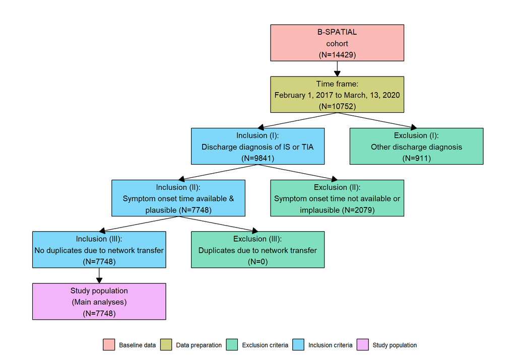

```r
dat_raw <- stroke_dat

dat_raw <- dat_raw %>%
  mutate(zip_loc=ifelse(zip_loc<10000,zip_loc+10000,zip_loc))

# inclusion
n_cohort <- dat_raw %>%
  nrow()

n_timeframe <- dat_raw %>%
  filter(year(adm_time) < "2021", year(adm_time) > "2016") %>%
  filter(adm_time >= "2017-02-01") %>%
  filter(adm_time <= "2020-03-14") %>%
  nrow()

n_inclusion1 <- dat_raw %>%
  filter(year(adm_time) < "2021", year(adm_time) > "2016") %>%
  filter(adm_time >= "2017-02-01") %>%
  filter(adm_time <= "2020-03-14") %>%
  filter(icd10=="1" | icd10=="2") %>%
  nrow()


n_inclusion2 <- dat_raw %>%
  filter(year(adm_time) < "2021", year(adm_time) > "2016") %>%
  filter(adm_time >= "2017-02-01") %>%
  filter(adm_time < "2020-03-13") %>%
  filter(icd10=="1" | icd10=="2") %>%
  filter(!is.na(onset_symp_time)) %>%
  nrow()

tast <- dat_raw %>%
  filter(year(adm_time) < "2021", year(adm_time) > "2016") %>%
  filter(adm_time >= "2017-02-01") %>%
  filter(adm_time < "2020-03-13") %>%
  filter(icd10=="1" | icd10=="2") %>%
  filter(!is.na(onset_symp_time)) %>%
 filter(!is.na(zip_loc)) %>%
  filter(zip_loc < "14200")

 n_inclusion3_df <- dat_raw %>%
  filter(year(adm_time) < "2021", year(adm_time) > "2016") %>%
  filter(adm_time >= "2017-02-01") %>%
  filter(adm_time < "2020-03-13") %>%
  filter(icd10=="1" | icd10=="2") %>%
  filter(!is.na(onset_symp_time))

# identify duplicates
duplicates <- tast  %>% # n_inclusion3_df
  mutate(int_transf_numb=ifelse(!is.na(transf_number), transf_number, ifelse(!is.na(displ_numb), displ_numb, NA))) %>% # mutate variable with all transfer numbers
  select(pat_id_exp, adm_time, onset_symp_time, sex, age, transf, int_transf_numb, transf_number, displ_numb, everything()) %>%
  filter(int_transf_numb==transf_number | int_transf_numb==displ_numb) %>% # filter by transf_number
  arrange(onset_symp_time, pat_id_exp) %>%
  group_by(int_transf_numb) %>%
  fill(transf_number, displ_numb, living_pre, walk_ability_pre, aht, dm, atr_fibr, prior_event, hlp, chd, pm, le_1, ci, pavk, nic, nic_quant, zip_loc, .direction = "downup") %>%
  filter(!is.na(transf_number) & !is.na(displ_numb))  # there were some single cases inside with only transf_numb or displ_numb but with no other match in other row

exclude_id <- duplicates %>%
  group_by(int_transf_numb) %>%
  slice(-1)

n_inclusion3_clean <- anti_join(n_inclusion3_df, exclude_id, by = "pat_id_exp")

n_inclusion3 <- n_inclusion3_clean %>%
  nrow()




# exclusion
dat_ex1 <- dat_raw %>%
  filter(year(adm_time) < "2021", year(adm_time) > "2016") %>%
  filter(adm_time >= "2017-02-01") %>%
  filter(adm_time < "2020-03-13")
n_exclusion1 <- dat_ex1 %>%
  filter(icd10=="3" | icd10=="4" | icd10=="5") %>%
  nrow()

dat_ex2 <- dat_raw %>%
  filter(year(adm_time) < "2021", year(adm_time) > "2016") %>%
  filter(adm_time >= "2017-02-01") %>%
  filter(adm_time < "2020-03-13") %>%
  filter(icd10=="1" | icd10=="2")
n_exclusion2 <- dat_ex2 %>%
  filter(is.na(onset_symp_time)) %>%
  nrow()

dat_ex3 <- dat_raw %>%
  filter(year(adm_time) < "2021", year(adm_time) > "2016") %>%
  filter(adm_time >= "2017-02-01") %>%
  filter(adm_time < "2020-03-13") %>%
  filter(icd10=="1" | icd10=="2") %>%
  filter(!is.na(onset_symp_time))
n_exclusion3 <- nrow(dat_ex3) - nrow(n_inclusion3_clean)

########## draw flowcharts

fc_main <- tibble(from = c("B-SPATIAL\ncohort\n(N=)",
                           "B-SPATIAL\ncohort\n(N=)",
                           "B-SPATIAL\ncohort\n(N=)",
                           "Time frame:\nFebruary 1, 2017 to March, 13, 2020\n(N=)",
                           "Time frame:\nFebruary 1, 2017 to March, 13, 2020\n(N=)",
                           "Inclusion (I):\nDischarge diagnosis of IS or TIA\n(N=)",
                           "Inclusion (I):\nDischarge diagnosis of IS or TIA\n(N=)",
                           "Inclusion (II):\nSymptom onset time available &\nplausible (N=)",
                           "Inclusion (II):\nSymptom onset time available &\nplausible (N=)",
                           "Inclusion (III):\nNo duplicates due to network transfer\n(N=)"),
                       to = c("Time frame:\nFebruary 1, 2017 to March, 13, 2020\n(N=)",
                              "Time frame:\nFebruary 1, 2017 to March, 13, 2020\n(N=)",
                              "Time frame:\nFebruary 1, 2017 to March, 13, 2020\n(N=)",
                              "Inclusion (I):\nDischarge diagnosis of IS or TIA\n(N=)",
                              "Exclusion (I):\nOther discharge diagnosis\n(N=)",
                              "Inclusion (II):\nSymptom onset time available &\nplausible (N=)",
                              "Exclusion (II):\nSymptom onset time not available or\nimplausible (N=)",
                              "Inclusion (III):\nNo duplicates due to network transfer\n(N=)",
                              "Exclusion (III):\nDuplicates due to network transfer\n(N=)",
                              "Study population\n(Main analyses)\n(N=)"))

fc_main$from[1] <- gsub("N=", paste0("N=", n_cohort, ""), fc_main$from[1])
fc_main$from[2] <- gsub("N=", paste0("N=", n_cohort, ""), fc_main$from[2])
fc_main$from[3] <- gsub("N=", paste0("N=", n_cohort, ""), fc_main$from[3])
fc_main$from[4] <- gsub("N=", paste0("N=", n_timeframe, ""), fc_main$from[4])
fc_main$from[5] <- gsub("N=", paste0("N=", n_timeframe, ""), fc_main$from[5])
fc_main$from[6] <- gsub("N=", paste0("N=", n_inclusion1, ""), fc_main$from[6])
fc_main$from[7] <- gsub("N=", paste0("N=", n_inclusion1, ""), fc_main$from[7])
fc_main$from[8] <- gsub("N=", paste0("N=", n_inclusion2, ""), fc_main$from[8])
fc_main$from[9] <- gsub("N=", paste0("N=", n_inclusion2, ""), fc_main$from[9])
fc_main$from[10] <- gsub("N=", paste0("N=", n_inclusion3, ""), fc_main$from[10])

fc_main$to[1] <- gsub("N=", paste0("N=", n_timeframe, ""), fc_main$to[1])
fc_main$to[2] <- gsub("N=", paste0("N=", n_timeframe, ""), fc_main$to[2])
fc_main$to[3] <- gsub("N=", paste0("N=", n_timeframe, ""), fc_main$to[3])
fc_main$to[4] <- gsub("N=", paste0("N=", n_inclusion1, ""), fc_main$to[4])
fc_main$to[5] <- gsub("N=", paste0("N=", n_exclusion1, ""), fc_main$to[5])
fc_main$to[6] <- gsub("N=", paste0("N=", n_inclusion2, ""), fc_main$to[6])
fc_main$to[7] <- gsub("N=", paste0("N=", n_exclusion2, ""), fc_main$to[7])
fc_main$to[8] <- gsub("N=", paste0("N=", n_inclusion3, ""), fc_main$to[8])
fc_main$to[9] <- gsub("N=", paste0("N=", n_exclusion3, ""), fc_main$to[9])
fc_main$to[10] <- gsub("N=", paste0("N=",n_inclusion3, ""), fc_main$to[10])


node_data_main <- tibble( name = c("B-SPATIAL\ncohort\n(N=14429)",
                                   "Time frame:\nFebruary 1, 2017 to March, 13, 2020\n(N=10752)",
                                   "Inclusion (I):\nDischarge diagnosis of IS or TIA\n(N=9841)",
                                   "Exclusion (I):\nOther discharge diagnosis\n(N=911)",
                                   "Inclusion (II):\nSymptom onset time available &\nplausible (N=7748)",
                                   "Exclusion (II):\nSymptom onset time not available or\nimplausible (N=2079)",
                                   "Inclusion (III):\nNo duplicates due to network transfer\n(N=7748)",
                                   "Exclusion (III):\nDuplicates due to network transfer\n(N=0)",
                                   "Study population\n(Main analyses)\n(N=7748)"), type = c("Baseline data",
                                                                                        "Data preparation",
                                                                                        "Inclusion criteria",
                                                                                        "Exclusion criteria",
                                                                                        "Inclusion criteria",
                                                                                        "Exclusion criteria",
                                                                                        "Inclusion criteria",
                                                                                        "Exclusion criteria",
                                                                                        "Study population"))

fc_main_gg <- ggflowchart(fc_main, node_data_main, fill=type, x_nudge = 0.42, y_nudge = 0.35)

fc_main_gg +
  labs(fill="") +
  theme(legend.position="bottom")
```

```r
summary_pm25_med_pand <- list(
 "Hourly PM 2.5 Median from March 14, 2020, to December 31, 2020 (includes pandemic)" = list(
    "Min" = ~ min(exposure_only_pandemic$pm25_median_h),
    "Median (IQR)" = ~ median_iqr(exposure_only_pandemic$pm25_median_h),
    "Mean (SD)" = ~ mean_sd(exposure_only_pandemic$pm25_median_h, denote_sd = "paren"),
    "Max" = ~ max(exposure_only_pandemic$pm25_median_h),
    "Missing (%)" = ~ n_perc0(is.na(pm25_median_h))
  )
)

tblq_pm25_med_pand <- summary_table(exposure_only_pandemic, summary_pm25_med_pand)
print(tblq_pm25_med_pand)
```

|  | exposure_only_pandemic (N = 7,080) |
| --- | --- |
| **Hourly PM 2.5 Median from March 14, 2020, to December 31, 2020 (includes pandemic)** |  |
| Min | 2.11 |
| Median (IQR) | 8.82 (5.87, 14.53) |
| Mean (SD) | 11.27 (7.56) |
| Max | 53.31 |
| Missing (%) | 0 (0) |

```r
print(tblq_pm25_med)
```

|  | exposure_pandemic (N = 34,320) |
| --- | --- |
| **Hourly PM2.5 Median from February 1, 2017, to December 31, 2020** |  |
| Min | 0.97 |
| Median (IQR) | 10.49 (6.74, 17.56) |
| Mean (SD) | 13.79 (10.28) |
| Max | 185.13 |
| Missing (%) | 0 (0) |

```r
summary_pm25_med_cc_pand <- list(
 "Hourly PM2.5 Median including pandemic exposures of cases and controls" = list(
   "Min" = ~ min(dat_analysis_only_pandemic$pm25_median_h, na.rm = TRUE),
    "Median (IQR)" = ~ median_iqr(dat_analysis_only_pandemic$pm25_median_h, na_rm = TRUE),
    "Mean (SD)" = ~ mean_sd(dat_analysis_only_pandemic$pm25_median_h, denote_sd = "paren", na_rm = TRUE),
    "Max" = ~ max(dat_analysis_only_pandemic$pm25_median_h, na.rm = TRUE),
    "Missing (%)" = ~ n_perc0(is.na(pm25_median_h_Z))
  )
)

tblq_pm25_med_cc_pand <- summary_table(dat_analysis_only_pandemic, summary_pm25_med_cc_pand)
print(tblq_pm25_med_cc_pand)
```

|  | dat_analysis_only_pandemic (N = 8,558) |
| --- | --- |
| **Hourly PM2.5 Median including pandemic exposures of cases and controls** |  |
| Min | 2.11 |
| Median (IQR) | 8,394; 8.22 (5.54, 13.41) |
| Mean (SD) | 8,394; 10.60 (7.21) |
| Max | 52.19 |
| Missing (%) | 164 (2) |

```r
##### table1: exposure_pandemic and adjustment variables in pandemic compared to previous years
exposure_pandemic$year <- as.numeric(format(exposure_pandemic$case_time, "%Y"))
exposure_pandemic$month <- as.numeric(format(exposure_pandemic$case_time, "%m"))

exposure_pandemic_tbl <- exposure_pandemic %>%
  filter(month > "3")

#complete_dat
dat_compl_pand <- exposure_pandemic_tbl

summary_tbl_complete_dat <- list(
  "Hourly PM2.5 Median" = list(
    "Min" = ~ min(dat_compl_pand$pm25_median_h, na.rm=TRUE),
    "Median (IQR)" = ~ median_iqr(dat_compl_pand$pm25_median_h, na_rm=TRUE),
    "Mean (SD)" = ~ mean_sd(dat_compl_pand$pm25_median_h, denote_sd = "paren",, na_rm=TRUE),
    "Max" = ~ max(dat_compl_pand$pm25_median_h, na.rm=TRUE),
    "Missing (%)" = ~ n_perc0(is.na(dat_compl_pand$pm25_median_h))
  )
)
tbl_compl_dat <- summary_table(dat_compl_pand, summary_tbl_complete_dat)


#2017
dat_2017_pand <- exposure_pandemic_tbl  %>%
  filter(year==2017)

summary_tbl_2017_pand <- list(
  "Hourly PM2.5 Median" = list(
    "Min" = ~ min(dat_2017_pand$pm25_median_h),
    "Median (IQR)" = ~ median_iqr(dat_2017_pand$pm25_median_h),
    "Mean (SD)" = ~ mean_sd(dat_2017_pand$pm25_median_h, denote_sd = "paren"),
    "Max" = ~ max(dat_2017_pand$pm25_median_h),
    "Missing (%)" = ~ n_perc0(is.na(dat_2017_pand$pm25_median_h))
  )
)
tbl_2017_pand <- summary_table(dat_2017_pand, summary_tbl_2017_pand)



#2018
dat_2018_pand <- exposure_pandemic_tbl  %>%
  filter(year==2018)

summary_tbl_2018_pand <- list(
  "Hourly PM2.5 Median" = list(
    "Min" = ~ min(dat_2018_pand$pm25_median_h),
    "Median (IQR)" = ~ median_iqr(dat_2018_pand$pm25_median_h),
    "Mean (SD)" = ~ mean_sd(dat_2018_pand$pm25_median_h, denote_sd = "paren"),
    "Max" = ~ max(dat_2018_pand$pm25_median_h),
    "Missing (%)" = ~ n_perc0(is.na(dat_2018_pand$pm25_median_h))
  )
)
tbl_2018_pand <- summary_table(dat_2018_pand, summary_tbl_2018_pand)


#2019
dat_2019_pand <- exposure_pandemic_tbl  %>%
  filter(year==2019)

summary_tbl_2019_pand <- list(
  "Hourly PM2.5 Median" = list(
    "Min" = ~ min(dat_2019_pand$pm25_median_h),
    "Median (IQR)" = ~ median_iqr(dat_2019_pand$pm25_median_h),
    "Mean (SD)" = ~ mean_sd(dat_2019_pand$pm25_median_h, denote_sd = "paren"),
    "Max" = ~ max(dat_2019_pand$pm25_median_h),
    "Missing (%)" = ~ n_perc0(is.na(dat_2019_pand$pm25_median_h))
  )
)
tbl_2019_pand <- summary_table(dat_2019_pand, summary_tbl_2019_pand)


#2020
dat_2020_pand <- exposure_pandemic_tbl  %>%
  filter(year==2020)

summary_tbl_2020_pand <- list(
  "Hourly PM2.5 Median" = list(
    "Min" = ~ min(dat_2020_pand$pm25_median_h),
    "Median (IQR)" = ~ median_iqr(dat_2020_pand$pm25_median_h),
    "Mean (SD)" = ~ mean_sd(dat_2020_pand$pm25_median_h, denote_sd = "paren"),
    "Max" = ~ max(dat_2020_pand$pm25_median_h),
    "Missing (%)" = ~ n_perc0(is.na(dat_2020_pand$pm25_median_h))
  )
)
tbl_2020_pand <- summary_table(dat_2020_pand, summary_tbl_2020_pand)

tbl_compl_pand <- cbind(tbl_2017_pand, tbl_2018_pand, tbl_2019_pand, tbl_2020_pand)
colnames(tbl_compl_pand) <- c(" ", "2017", "2018","2019","2020")
print(tbl_compl_pand)
```

```
##
##
## |                          |dat_2017_pand (N = 4,392) |dat_2018_pand (N = 4,392) |dat_2019_pand (N = 4,392) |dat_2020_pand (N = 4,392) |
## |:-------------------------|:-------------------------|:-------------------------|:-------------------------|:-------------------------|
## |**Hourly PM2.5 Median**   |&nbsp;&nbsp;              |&nbsp;&nbsp;              |&nbsp;&nbsp;              |&nbsp;&nbsp;              |
## |&nbsp;&nbsp; Min          |1.4                       |1.88                      |1.73                      |2.51                      |
## |&nbsp;&nbsp; Median (IQR) |9.62 (6.73, 14.87)        |9.37 (6.51, 14.34)        |9.00 (6.41, 13.22)        |7.64 (5.47, 11.26)        |
## |&nbsp;&nbsp; Mean (SD)    |11.97 (7.45)              |11.58 (7.34)              |10.77 (6.22)              |9.16 (5.19)               |
## |&nbsp;&nbsp; Max          |58.425                    |60.52                     |50.49                     |35.27                     |
## |&nbsp;&nbsp; Missing (%)  |0 (0)                     |0 (0)                     |0 (0)                     |0 (0)                     |
```

|  | Adjusted Model with pandemic measures and pandemic adjustment (February 1, 2017 - December 31, 2020) Est. | Adjusted Model with pandemic measures and pandemic adjustment (February 1, 2017 - December 31, 2020) 2.5 % | Adjusted Model with pandemic measures and pandemic adjustment (February 1, 2017 - December 31, 2020) 97.5 % | Adjusted Model with pandemic measures and pandemic adjustment (February 1, 2017 - December 31, 2020) S.E. | Adjusted Model with pandemic measures and pandemic adjustment (February 1, 2017 - December 31, 2020) t | Adjusted Model with pandemic measures and pandemic adjustment (February 1, 2017 - December 31, 2020) p | Adjusted Model with pandemic measures but without pandemic adjustment (February 1, 2017 - December 31, 2020) Est. | Adjusted Model with pandemic measures but without pandemic adjustment (February 1, 2017 - December 31, 2020) 2.5 % | Adjusted Model with pandemic measures but without pandemic adjustment (February 1, 2017 - December 31, 2020) 97.5 % | Adjusted Model with pandemic measures but without pandemic adjustment (February 1, 2017 - December 31, 2020) S.E. | Adjusted Model with pandemic measures but without pandemic adjustment (February 1, 2017 - December 31, 2020) t | Adjusted Model with pandemic measures but without pandemic adjustment (February 1, 2017 - December 31, 2020) p | Timely restricted Model without pandemic measures and adjustment (February 1, 2017 - March 13, 2020) Est. | Timely restricted Model without pandemic measures and adjustment (February 1, 2017 - March 13, 2020) 2.5 % | Timely restricted Model without pandemic measures and adjustment (February 1, 2017 - March 13, 2020) 97.5 % | Timely restricted Model without pandemic measures and adjustment (February 1, 2017 - March 13, 2020) S.E. | Timely restricted Model without pandemic measures and adjustment (February 1, 2017 - March 13, 2020) t | Timely restricted Model without pandemic measures and adjustment (February 1, 2017 - March 13, 2020) p |
| --- | --- | --- | --- | --- | --- | --- | --- | --- | --- | --- | --- | --- | --- | --- | --- | --- | --- | --- |
| PM 2.5 [µg/m3] | 1.020 | 0.994 | 1.047 | 0.013 | 1.493 | 0.135 | 1.019 | 0.993 | 1.046 | 0.013 | 1.433 | 0.152 | 1.017 | 0.988 | 1.046 | 0.015 | 1.136 | 0.256 |
| Barometric pressure [hPa], df = 1 | 0.943 | 0.870 | 1.022 | 0.039 | -1.426 | 0.154 | 0.931 | 0.860 | 1.008 | 0.038 | -1.772 | 0.076 | 0.962 | 0.880 | 1.052 | 0.044 | -0.845 | 0.398 |
| Relative humidity [%], df = 1 | 0.927 | 0.824 | 1.042 | 0.056 | -1.268 | 0.205 | 0.940 | 0.836 | 1.057 | 0.056 | -1.036 | 0.300 | 0.915 | 0.805 | 1.040 | 0.060 | -1.358 | 0.175 |
| Temperature [°C], df = 1 | 0.856 | 0.723 | 1.012 | 0.073 | -1.817 | 0.069 | 0.859 | 0.726 | 1.016 | 0.074 | -1.777 | 0.076 | 0.865 | 0.718 | 1.043 | 0.083 | -1.514 | 0.130 |
| Public Holidays | 0.910 | 0.796 | 1.041 | 0.062 | -1.376 | 0.169 | 0.915 | 0.801 | 1.046 | 0.062 | -1.294 | 0.196 | 0.939 | 0.810 | 1.089 | 0.071 | -0.832 | 0.405 |
| Pandemic | 0.734 | 0.548 | 0.984 | 0.110 | -2.071 | 0.038 |  |  |  |  |  |  |  |  |  |  |  |  |
| Num.Obs. | 42073 |  |  |  |  |  | 42073 |  |  |  |  |  | 33272 |  |  |  |  |  |

Call: clogit(stroke ~ pm25_median_h_Z + strata(strata) + nsk(hour_med_AP, df = 1) + nsk(hour_med_RH, df = 1) + nsk(hour_med_TM, df = 1) + holidays, dat_analysis_13)

```
                       coef exp(coef) se(coef)    z   p
```

pm25_median_h_Z 0.017 1.017 0.015 1.1 0.3 nsk(hour_med_AP, df = 1) -0.039 0.962 0.046 -0.8 0.4 nsk(hour_med_RH, df = 1) -0.089 0.915 0.066 -1.4 0.2 nsk(hour_med_TM, df = 1) -0.145 0.865 0.096 -1.5 0.1 holidaysYes -0.063 0.939 0.075 -0.8 0.4

Likelihood ratio test=4.7 on 5 df, p=0.45 n= 33272, number of events= 7635 Call: clogit(stroke ~ pm25_median_h_Z + strata(strata) + nsk(hour_med_AP, df = 1) + nsk(hour_med_RH, df = 1) + nsk(hour_med_TM, df = 1) + holidays + pandemic, dat_analysis_pan_adj)

```
                       coef exp(coef) se(coef)    z    p
```

pm25_median_h_Z 0.020 1.020 0.013 1.5 0.14 nsk(hour_med_AP, df = 1) -0.058 0.943 0.041 -1.4 0.15 nsk(hour_med_RH, df = 1) -0.076 0.927 0.060 -1.3 0.20 nsk(hour_med_TM, df = 1) -0.156 0.856 0.086 -1.8 0.07 holidaysYes -0.094 0.910 0.068 -1.4 0.17 pandemicYes -0.309 0.734 0.149 -2.1 0.04

Likelihood ratio test=13 on 6 df, p=0.048 n= 42073, number of events= 9565 Call: clogit(stroke ~ pm25_median_h_Z + strata(strata) + nsk(hour_med_AP, df = 1) + nsk(hour_med_RH, df = 1) + nsk(hour_med_TM, df = 1) + holidays, dat_analysis_pan_adj)

```
                       coef exp(coef) se(coef)    z    p
```

pm25_median_h_Z 0.019 1.019 0.013 1.4 0.15 nsk(hour_med_AP, df = 1) -0.072 0.931 0.040 -1.8 0.08 nsk(hour_med_RH, df = 1) -0.062 0.940 0.060 -1.0 0.30 nsk(hour_med_TM, df = 1) -0.152 0.859 0.086 -1.8 0.08 holidaysYes -0.088 0.915 0.068 -1.3 0.20

Likelihood ratio test=8.4 on 5 df, p=0.13 n= 42073, number of events= 9565

#### **Single ischemic stroke (IS) and single transient ischemic attack (TIA) analyses**

Differentiation into single ischemic stroke (IS) and single transient ischemic attack (TIA) analyses

```r
dat_analysis_pan_adj_TIA <- dat_analysis_pan_adj %>%
  filter(icd10=="G45-0 - G45-3, G45-8 - G45-9 (TIA)")

dat_analysis_pan_adj_IS <- dat_analysis_pan_adj %>%
  filter(icd10 =="I63-I64 (ischemic stroke)")

model_sens_IS_TIA <- list(
  "Only TIA" = clogit(stroke ~ pm25_median_h_Z +strata(strata) +
                                   nsk(hour_med_AP, df = 1) +
                                   nsk(hour_med_RH, df = 1) +
                                   nsk(hour_med_TM, df = 1) +
                                   holidays +
                                   pandemic,dat_analysis_pan_adj_TIA),
  "Only IS" = clogit(stroke ~ pm25_median_h_Z +strata(strata) +
                                   nsk(hour_med_AP, df = 1) +
                                   nsk(hour_med_RH, df = 1) +
                                   nsk(hour_med_TM, df = 1) +
                                   holidays +
                                   pandemic,dat_analysis_pan_adj_IS))

print(model_sens_IS_TIA)
```

$`Only TIA` Call: clogit(stroke ~ pm25_median_h_Z + strata(strata) + nsk(hour_med_AP, df = 1) + nsk(hour_med_RH, df = 1) + nsk(hour_med_TM, df = 1) + holidays + pandemic, dat_analysis_pan_adj_TIA)

```
                        coef exp(coef) se(coef)    z    p
```

pm25_median_h_Z 0.0084 1.0084 0.0283 0.3 0.77 nsk(hour_med_AP, df = 1) -0.0708 0.9317 0.0885 -0.8 0.42 nsk(hour_med_RH, df = 1) 0.0498 1.0510 0.1287 0.4 0.70 nsk(hour_med_TM, df = 1) 0.0306 1.0311 0.1802 0.2 0.87 holidaysYes -0.1929 0.8245 0.1476 -1.3 0.19 pandemicYes -0.5857 0.5567 0.2995 -2.0 0.05

Likelihood ratio test=7.8 on 6 df, p=0.25 n= 9239, number of events= 2097

$`Only IS` Call: clogit(stroke ~ pm25_median_h_Z + strata(strata) + nsk(hour_med_AP, df = 1) + nsk(hour_med_RH, df = 1) + nsk(hour_med_TM, df = 1) + holidays + pandemic, dat_analysis_pan_adj_IS)

```
                       coef exp(coef) se(coef)    z    p
```

pm25_median_h_Z 0.023 1.023 0.015 1.5 0.13 nsk(hour_med_AP, df = 1) -0.055 0.946 0.046 -1.2 0.23 nsk(hour_med_RH, df = 1) -0.113 0.893 0.068 -1.7 0.10 nsk(hour_med_TM, df = 1) -0.210 0.811 0.097 -2.2 0.03 holidaysYes -0.067 0.935 0.077 -0.9 0.39 pandemicYes -0.210 0.811 0.173 -1.2 0.23

Likelihood ratio test=9.5 on 6 df, p=0.15 n= 32834, number of events= 7468

```r
modelsummary(model_sens_IS_TIA,
             coef_rename = c("pm25_median_h_Z_sIQR" = "PM 2.5 [µg/m3]",
                             "nsk(hour_med_AP, df = 3)1" = "Barometric pressure [hPa], df = 1",
                             "nsk(hour_med_AP, df = 3)2" = "Barometric pressure [hPa], df = 2",
                             "nsk(hour_med_AP, df = 3)3" = "Barometric pressure [hPa], df = 3",
                             "nsk(hour_med_RH, df = 3)1" = "Relative humidity [%], df = 1",
                             "nsk(hour_med_RH, df = 3)2" = "Relative humidity [%], df = 2",
                             "nsk(hour_med_RH, df = 3)3" = "Relative humidity [%], df = 3",
                             "nsk(hour_med_TM, df = 3)1" = "Temperature [°C], df = 1",
                             "nsk(hour_med_TM, df = 3)2" = "Temperature [°C], df = 2",
                             "nsk(hour_med_TM, df = 3)3" = "Temperature [°C], df = 3",
                             "holidaysYes" = "Public Holidays",
                             "pandemicYes" = "Pandemic"),
             estimate = "estimate",
            statistic = c("conf.int",
                           "{std.error}",
                           "{statistic}",
                           "{p.value}"),
             shape = term ~ model + statistic,
             conf_level=.95,
             output = "html",
             fmt=3,
             exponentiate = TRUE,
            gof_map = c("nobs"))
```

|  | Only TIA Est. | Only TIA 2.5 % | Only TIA 97.5 % | Only TIA S.E. | Only TIA t | Only TIA p | Only IS Est. | Only IS 2.5 % | Only IS 97.5 % | Only IS S.E. | Only IS t | Only IS p |
| --- | --- | --- | --- | --- | --- | --- | --- | --- | --- | --- | --- | --- |
| pm25_median_h_Z | 1.008 | 0.954 | 1.066 | 0.029 | 0.296 | 0.767 | 1.023 | 0.993 | 1.053 | 0.015 | 1.516 | 0.129 |
| nsk(hour_med_AP, df = 1) | 0.932 | 0.783 | 1.108 | 0.082 | -0.800 | 0.424 | 0.946 | 0.864 | 1.036 | 0.044 | -1.196 | 0.232 |
| nsk(hour_med_RH, df = 1) | 1.051 | 0.817 | 1.352 | 0.135 | 0.387 | 0.699 | 0.893 | 0.781 | 1.021 | 0.061 | -1.660 | 0.097 |
| nsk(hour_med_TM, df = 1) | 1.031 | 0.724 | 1.468 | 0.186 | 0.170 | 0.865 | 0.811 | 0.670 | 0.981 | 0.079 | -2.156 | 0.031 |
| Public Holidays | 0.825 | 0.617 | 1.101 | 0.122 | -1.307 | 0.191 | 0.935 | 0.804 | 1.088 | 0.072 | -0.868 | 0.385 |
| Pandemic | 0.557 | 0.310 | 1.001 | 0.167 | -1.955 | 0.051 | 0.811 | 0.577 | 1.139 | 0.141 | -1.211 | 0.226 |
| Num.Obs. | 9239 |  |  |  |  |  | 32834 |  |  |  |  |  |

### Plots

- **SECONDARY ANALYSIS**
- SINGLE LAG ANALYSES

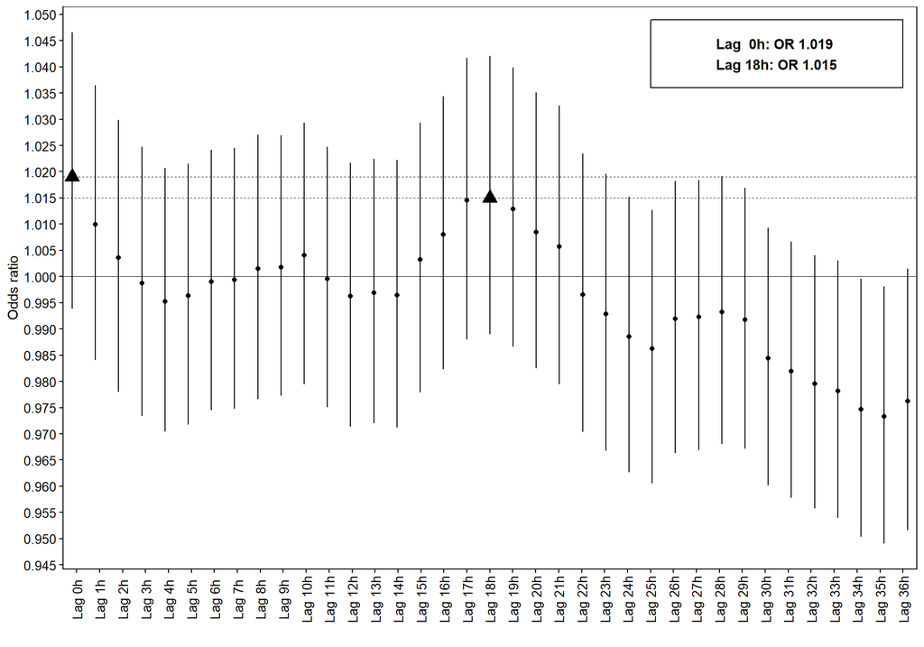

**Single Lag Analysis**: Effect of PM 2.5 exposure on ischemic stroke 0-36 hours previous to the index stroke event”  
* CUMULATIVE LAG ANALYSES

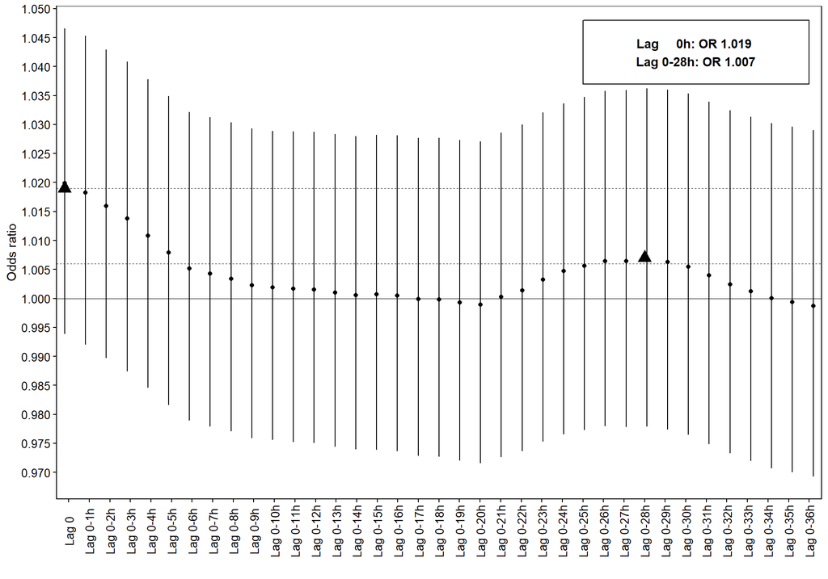

**Cumulative Lag Analysis**: Effect of PM 2.5 exposure on ischemic stroke 0-36 hours previous to the index stroke event  
* **SENSITIVITY ANALYSES**  
CAVE: All information maps are based on a low number of participants (only patients with zip code information available)

```
## Ignoring unknown labels:
## • size : "0.5"
```

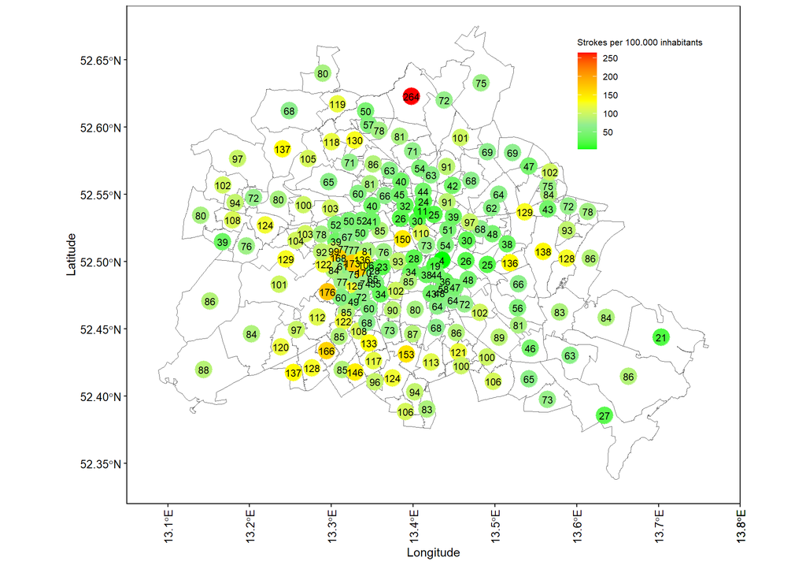

```r
options(digits = 7)

#### load

geo_DE <- read.delim("S:\\Fakultaet\\MFZ\\MFZ-CSB\\REG-B-SPATIAL\\Jakob\\PM25_stroke\\sens_analysis_km\\DE.txt")
geo_plz_berlin <- geojson_sf("S:\\Fakultaet\\MFZ\\MFZ-CSB\\REG-B-SPATIAL\\Jakob\\PM25_stroke\\maps\\plz-berlin.geojson")
zip_pop <- read_csv("S:\\Fakultaet\\MFZ\\MFZ-CSB\\REG-B-SPATIAL\\Jakob\\PM25_stroke\\IS_TIA\\042024_code_review\\25072024_zip_population.csv")
zip_pop <- zip_pop %>%
    separate(`zip;population`, into = c("zip", "population"), sep = ";") %>%
  rename(zip_code = zip)

zip_pop$zip_code <- as.integer(zip_pop$zip_code)



#### Prepare

geo_Berlin <- geo_DE %>%
  filter(BB == "BE")

colnames(geo_Berlin)[2] = "zip_code"
colnames(geo_Berlin)[10] = "latitude"
colnames(geo_Berlin)[11] = "longitude"

geo_Berlin <- geo_Berlin[,-(1)]
geo_Berlin <- geo_Berlin[,-(2:8)]
geo_Berlin <- geo_Berlin[,-(4)]

#### Counting

counts <- table(dat_zip$zip_loc) # count strokes by zip code

comb_geo_Berlin <- merge(geo_Berlin, data.frame(zip_code = names(counts), count = as.integer(counts), all.x = TRUE, by = 'zip_code'))

comb_geo_Berlin$count[is.na(comb_geo_Berlin$count)] <- 0

comb_geo_Berlin <- left_join(comb_geo_Berlin, zip_pop, by = "zip_code")

comb_geo_Berlin$count <- as.numeric(comb_geo_Berlin$count)
comb_geo_Berlin$population <- as.numeric(comb_geo_Berlin$population)

comb_geo_Berlin <- comb_geo_Berlin %>%
  mutate(incidence_100 = round((count/population)*100000))

comb_geo_Berlin <- comb_geo_Berlin %>%
  mutate(inc_cat = cut(incidence_100,
                       breaks = c(-Inf, 99, 199, Inf),
                       labels = c("0-99", "100-199", "200+"),
                       include.lowest = TRUE))

#inc_cat_quant <- quantile(comb_geo_Berlin$incidence_100, probs = seq(0,1, length.out = 5))

#comb_geo_Berlin <- comb_geo_Berlin %>%
#  mutate(inc_cat = cut(incidence_100, breaks = inc_cat_quant, labels = c("Low", "Medium-Low", "Medium-High", "High"), include.lowest = TRUE))

#print(comb_geo_Berlin)
BLUME_MC <- data.frame(longitude = c(13.34994,
                                     13.430927,
                                     13.417765,
                                     13.225292,
                                     13.483272,
                                     13.647074,
                                     13.318261,
                                     13.387406,
                                     13.441162,
                                     13.469914,
                                     13.382760), latitude = c(52.542428,
                                                              52.489235,
                                                              52.513512,
                                                              52.473457,
                                                              52.644095,
                                                              52.447722,
                                                              52.463584,
                                                              52.438244,
                                                              52.467425,
                                                              52.514060,
                                                              52.509750)) # MC-stations

BLUME_BG_MC <- data.frame(longitude = c(13.34994,
                                     13.430927,
                                     13.417765), latitude = c(52.542428,
                                                              52.489235,
                                                              52.513512)) # BG_MC-stations
BLUME_OS_MC <- data.frame(longitude = c(13.225292,
                                          13.483272,
                                          13.647074), latitude = c(52.473457,
                                                                     52.644095,
                                                                     52.447722)) # OS_MC-stations
BLUME_T_MC <- data.frame(longitude = c(13.318261,
                                       13.387406,
                                       13.441162,
                                       13.469914,
                                       13.382760), latitude = c(52.463584,
                                                                 52.438244,
                                                                 52.467425,
                                                                 52.514060,
                                                                 52.509750)) # OS_MC-stations

DWD_MC <- data.frame(longitude = c(13.301700,
                                   13.530600,
                                   13.402100), latitude=c(52.45300,
                                                          52.38000,
                                                          52.46700)) # 403-Dahlem, 427-Brandenburg Flughafen, 433-Tempelhof

MC_stations <- c("MC010","MC042","MC171","MC032","MC077","MC085","MC117","MC124","MC144","MC174","MC190")
BG_MC_stations <- c("MC010","MC042","MC171")
OS_MC_stations <- c("MC032","MC077","MC085")
T_MC_stations <- c("MC117","MC124","MC144","MC174","MC190")
DWD_MC_stations <- c("403 (Dahlem)", "427 (Airport Schönefeld)", "433 (Tempelhof)")

BLUME_MC_sf <- st_as_sf(BLUME_MC, coords = c("longitude", "latitude"), crs = 4326)
BLUME_BG_MC_sf <- st_as_sf(BLUME_BG_MC, coords = c("longitude", "latitude"), crs = 4326)
BLUME_OS_MC_sf <- st_as_sf(BLUME_OS_MC, coords = c("longitude", "latitude"), crs = 4326)
BLUME_T_MC_sf <- st_as_sf(BLUME_T_MC, coords = c("longitude", "latitude"), crs = 4326)
DWD_MC_sf <- st_as_sf(DWD_MC, coords = c("longitude", "latitude"), crs = 4326)

BLUME_MC_sf_buffered <- st_buffer(BLUME_MC_sf, dist = 5000) # distance in meters
BLUME_BG_MC_sf_buffered <- st_buffer(BLUME_BG_MC_sf, dist = 5000) # distance in meters
BLUME_OS_MC_sf_buffered <- st_buffer(BLUME_OS_MC_sf, dist = 5000) # distance in meters
BLUME_T_MC_sf_buffered <- st_buffer(BLUME_T_MC_sf, dist = 5000) # distance in meters
DWD_MC_sf_buffered <- st_buffer(DWD_MC_sf, dist = 5000) # distance in meters

#### Mapping

geo_Berlin_sf <- st_as_sf(comb_geo_Berlin, coords = c("longitude", "latitude"), crs = 4326)

#geo_Berlin_sf_buffered <- st_buffer(geo_Berlin_sf, dist = 5000) # distance in meters


# map with incidence (coloured)
geo_Berlin_inc_100_col <- ggplot() +
  geom_sf(data = st_as_sf(geo_plz_berlin), fill = "white") +
  geom_point(data = comb_geo_Berlin, aes(x = longitude, y = latitude, colour = incidence_100),
            size = 7) +
   theme_classic(base_size = 11) +
  theme(axis.text.x = element_text(size=10, angle=90, vjust = 0.5)) +
  theme(axis.text.y = element_text(size=10, vjust = 0.5)) +
  xlab("Longitude") +
  ylab("Latitude") +
  theme(
    legend.position = c(.95, .95),
    legend.justification = c("right", "top"),
    legend.box.just = "right",
    legend.margin = margin(6, 6, 6, 6), legend.title = element_text(size = 8),
               legend.text = element_text(size = 8),
         panel.border = element_rect(color = "black", fill = NA, size = 0.5)) +
  geom_text(data = comb_geo_Berlin, aes(x = longitude, y = latitude, label = incidence_100),
            size =3, color = "black") +
  coord_sf(xlim = c(13.05, 13.8), ylim = c(52.32, 52.69), expand = FALSE) +

   scale_color_gradientn(colors = c("green", "lightgreen", "yellow", "orange", "red")) +
  labs(colour = "Strokes per 100.000 inhabitants", size = 0.5)

print(geo_Berlin_inc_100_col)
```

```
## Ignoring unknown labels:
## • size : "0.5"
```

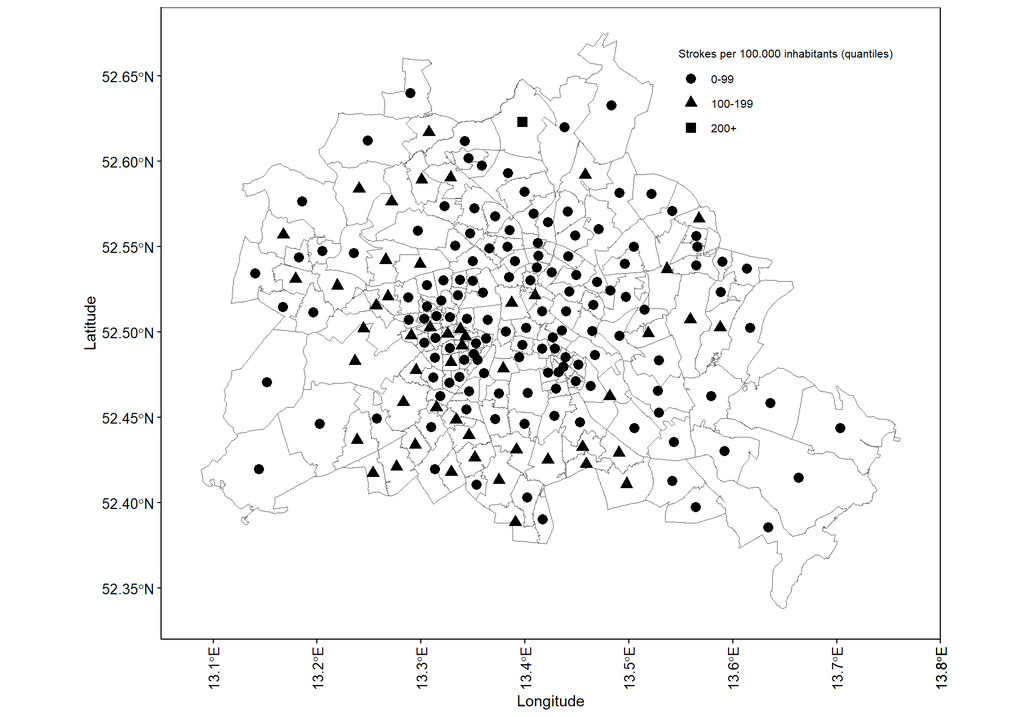

```r
# map with incidence (shaped)
geo_Berlin_inc_100_shape <- ggplot() +
  geom_sf(data = st_as_sf(geo_plz_berlin), fill = "white") +
  geom_point(data = comb_geo_Berlin, aes(x = longitude, y = latitude, shape = factor(inc_cat)),
            size = 3) +
   theme_classic(base_size = 11) +
  theme(axis.text.x = element_text(size=10, angle=90, vjust = 0.5)) +
  theme(axis.text.y = element_text(size=10, vjust = 0.5)) +
  xlab("Longitude") +
  ylab("Latitude") +
  theme(
    legend.position = c(.95, .95),
    legend.justification = c("right", "top"),
    legend.box.just = "right",
    legend.margin = margin(6, 6, 6, 6), legend.title = element_text(size = 8),
               legend.text = element_text(size = 8),
         panel.border = element_rect(color = "black", fill = NA, size = 0.5)) +
  # geom_text(data = comb_geo_Berlin, aes(x = longitude, y = latitude, label = incidence_100),
  #           size =3, color = "black") +
  coord_sf(xlim = c(13.05, 13.8), ylim = c(52.32, 52.69), expand = FALSE) +
  labs(shape = "Strokes per 100.000 inhabitants (quantiles)", size = 0.5)

print(geo_Berlin_inc_100_shape)
```

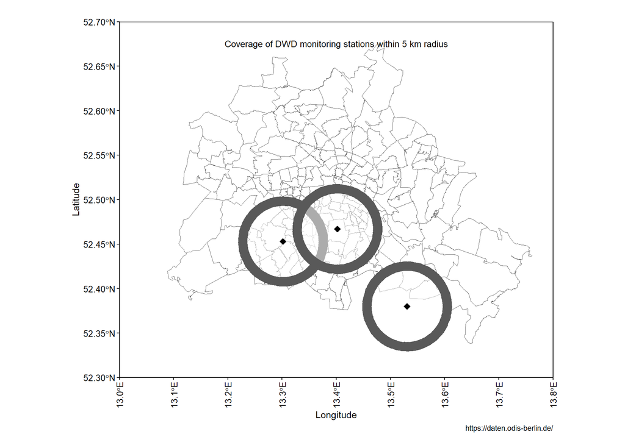

```r
# # map with strokes and grouped stations (colours)
# geo_Berlin_plz_stroke_col_single <- ggplot() +
#   geom_sf(data = st_as_sf(geo_plz_berlin), fill = "white") +
#   geom_point(data = comb_geo_Berlin, aes(x = longitude, y = latitude, colour = count),
#              size = 3) +
#   geom_sf(data = BLUME_BG_MC_sf_buffered, fill = "orange4", color = "orange4", alpha = 0.3, size = 10) +
#   geom_sf(data = BLUME_OS_MC_sf_buffered, fill = "palegreen4", color = "palegreen4", alpha = 0.3, size = 10) +
#   geom_sf(data = BLUME_T_MC_sf_buffered, fill = "red4", color = "red4", alpha = 0.3, size = 10) +
#   geom_sf(data = BLUME_BG_MC_sf, fill = "orange4", color = "black", alpha = 1, size = 2) +
#   geom_sf(data = BLUME_OS_MC_sf, fill = "palegreen4", color = "black", alpha = 1, size = 2) +
#   geom_sf(data = BLUME_T_MC_sf, fill = "red4", color = "black", alpha = 1, size = 2) +
#   geom_text(data = comb_geo_Berlin, aes(x = longitude, y = latitude, label = count),
#             size = 2, color = "white") +
#   coord_sf(xlim = c(13.0, 13.8), ylim = c(52.3, 52.7), expand = FALSE) +
#   labs(
#     title = "Ischemic stroke occurence by Berlin zip code areas",
#     subtitle = "February 1, 2017 to March 20, 2020",
#     caption = "https://daten.odis-berlin.de/") +
#   theme(plot.title = element_text(size = 8.5), plot.subtitle = element_text(size = 8), plot.caption = element_text(size = 6))  +
#   scale_color_gradient(low="blue", high="red") +
#   labs(colour = "Strokes per area", size = 0.5)
#
# print(geo_Berlin_plz_stroke_col_single)
#
# ggsave("29022024_first_draft_smaller.png", geo_Berlin_plz_stroke_col_single, dpi = 800)






# map with DWD MC BG


geo_Berlin_DWD_cov <- ggplot() +
  geom_sf(data = st_as_sf(geo_plz_berlin), fill = "white") +
  geom_sf(data = DWD_MC_sf_buffered, fill = "white", alpha = 0.5,  size = 5) +
  # geom_text(data = comb_geo_Berlin, aes(x = longitude, y = latitude, label = count),
  #           size = 2, color = "darkred") +
  coord_sf(xlim = c(13.0, 13.8), ylim = c(52.3, 52.7), expand = FALSE) +
  labs(
    caption = "https://daten.odis-berlin.de/") +
  theme(plot.title = element_text(size = 8.5), plot.subtitle = element_text(size = 8), plot.caption = element_text(size = 6)) +
   theme_classic(base_size = 11) +
  theme(axis.text.x = element_text(size=10, angle=90, vjust = 0.5)) +
  theme(axis.text.y = element_text(size=10, vjust = 0.5)) +
  xlab("Longitude") +
  ylab("Latitude") +
   theme(
    legend.position = c(.95, .95),
    legend.justification = c("right", "top"),
    legend.box.just = "right",
    legend.margin = margin(6, 6, 6, 6), legend.title = element_text(size = 8),
               legend.text = element_text(size = 8),
         panel.border = element_rect(color = "black", fill = NA, size = 0.5)) +
    geom_point(data = DWD_MC, aes(x = longitude, y = latitude), size = 3,
             shape = 18, colour = "black", stroke = 1) +
  ggtitle("Coverage of DWD monitoring stations within 5 km radius")+
  theme(plot.title=element_text(size=10, margin=margin(t=40,b=-30), hjust=0.5, vjust=0.5))

print(geo_Berlin_DWD_cov)
```

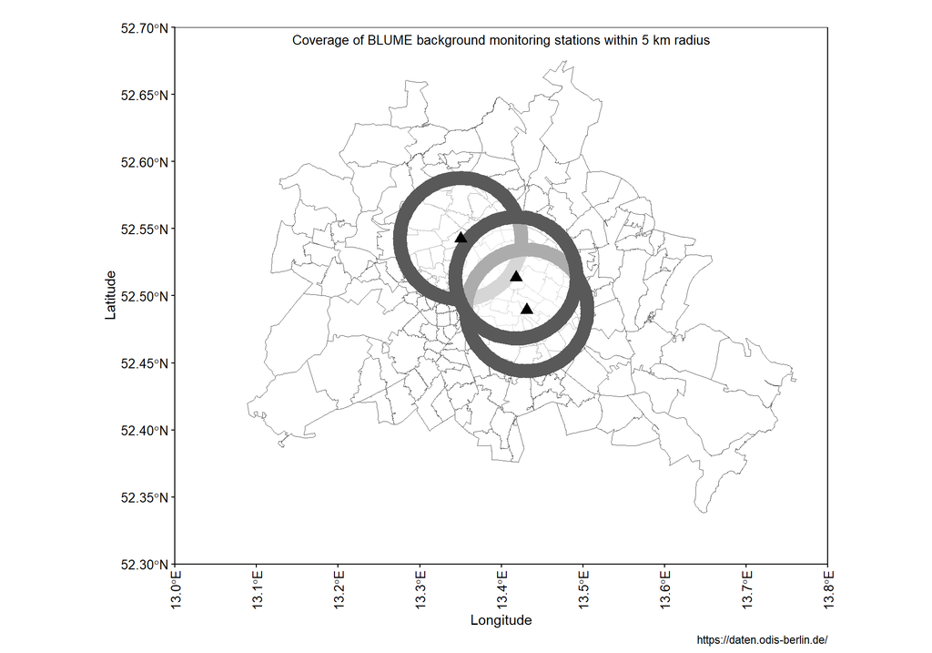

```r
# map with BLUME MC BG
geo_Berlin_BLUME_cov <- ggplot() +
  geom_sf(data = st_as_sf(geo_plz_berlin), fill = "white") +
  geom_sf(data = BLUME_BG_MC_sf_buffered, fill = "white", alpha = 0.5,  size = 5) +
  # geom_text(data = comb_geo_Berlin, aes(x = longitude, y = latitude, label = count),
  #           size = 2, color = "darkred") +
  coord_sf(xlim = c(13.0, 13.8), ylim = c(52.3, 52.7), expand = FALSE) +
  labs(
    title = "Coverage of BLUME background monitoring stations within 5 km radius",
    subtitle = "",
    caption = "https://daten.odis-berlin.de/"
  ) +
  theme(plot.title = element_text(size = 8.5), plot.subtitle = element_text(size = 8), plot.caption = element_text(size = 6)) +
   theme_classic(base_size = 11) +
  theme(axis.text.x = element_text(size=10, angle=90, vjust = 0.5)) +
  theme(axis.text.y = element_text(size=10, vjust = 0.5)) +
  xlab("Longitude") +
  ylab("Latitude") +
   theme(
    legend.position = c(.95, .95),
    legend.justification = c("right", "top"),
    legend.box.just = "right",
    legend.margin = margin(6, 6, 6, 6), legend.title = element_text(size = 8),
               legend.text = element_text(size = 8),
         panel.border = element_rect(color = "black", fill = NA, size = 0.5)) +
    geom_point(data = BLUME_BG_MC, aes(x = longitude, y = latitude), size = 3,
             shape = 17, colour = "black", stroke = 1) +
  ggtitle("Coverage of BLUME background monitoring stations within 5 km radius")+
  theme(plot.title=element_text(size=10, margin=margin(t=20,b=-30), hjust=0.5, vjust=0.5))

print(geo_Berlin_BLUME_cov)
```

```r
# # map with zip codes
# geo_Berlin_plz <- ggplot() +
#   geom_sf(data = st_as_sf(geo_plz_berlin), fill = "antiquewhite") +
#   geom_sf(data = BLUME_MC_sf_buffered, fill = "darkgreen", alpha = 0.2, size = 1.5) +
#   geom_text(data = comb_geo_Berlin, aes(x = longitude, y = latitude, label = zip_code),
#             size = 1, color = "darkred") +
#   geom_point(data = BLUME_MC, aes(x = longitude, y = latitude), size = 1,
#              shape = 20, colour = "black", stroke = 1) +
#   coord_sf(xlim = c(13.0, 13.8), ylim = c(52.3, 52.7), expand = FALSE) +
#   labs(
#     title = "Berlin zip codes areas with numbers of B-SPATIAL ischemic strokes",
#     subtitle = "February 1, 2017 to March 20, 2020; 5 km radius around BG stations",
#     caption = "https://daten.odis-berlin.de/"
#   ) +
#   theme(plot.title = element_text(size = 8.5), plot.subtitle = element_text(size = 8), plot.caption = element_text(size = 6))
#
#
# print(geo_Berlin_plz)
```

* **OTHER**

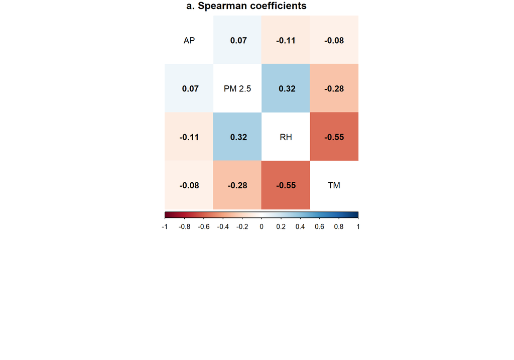

```r
# SPEARSON
corr_spear <- all_dat %>%
  select(pm25_median_h, hour_med_AP, hour_med_RH, hour_med_TM) %>%
  cor(use="complete.obs", method = "spearman")
colnames(corr_spear) <- c("PM 2.5", "AP", "RH", "TM")
rownames(corr_spear) <- c("PM 2.5", "AP", "RH", "TM")
corrplot(corr_spear, method = "color", type = "full", order = "alphabet", tl.cex = 1, tl.col = 'black', addCoef.col = "black", main="a. Spearman coefficients", mar = c(12,0,1,2), cl.pos = 'b', tl.pos = 'd', diag = FALSE)
```

[figure not shown]

```r
testRes = cor.mtest(corr_spear, conf.level = 0.95)
colnames(corr_spear) <- c("PM 2.5", "AP", "RH", "TM")
rownames(corr_spear) <- c("PM 2.5", "AP", "RH", "TM")

# PEARSON
corr_pear <- all_dat %>%
  select(pm25_median_h, hour_med_AP, hour_med_RH, hour_med_TM) %>%
  cor(use="complete.obs", method = "spearman")
colnames(corr_pear) <- c("PM 2.5", "AP", "RH", "TM")
rownames(corr_pear) <- c("PM 2.5", "AP", "RH", "TM")
corrplot(corr_pear, method = "color", type = "full", order = "alphabet", tl.cex = 1, tl.col = 'black', addCoef.col = "black", main="b. Pearman coefficients", mar = c(12,0,1,2), cl.pos = 'b', tl.pos = 'd', diag = FALSE)
```

```r
testRes = cor.mtest(corr_pear, conf.level = 0.95)
colnames(corr_pear) <- c("PM 2.5", "AP", "RH", "TM")
rownames(corr_pear) <- c("PM 2.5", "AP", "RH", "TM")
```

### Limitations

- **Testing graphical causal models** was not feasible.
- **Measurement error analyses** was not succesful due to a low number of zip-code information.